# OncoSimulR: forward genetic simulation in asexual populations with arbitrary epistatic interactions and a focus on modeling tumor progression.

### 2.2.1 Common use cases, set 1.

We will use the Exp and the McFL models, run with different parameters. The script is provided as ‘benchmark_2.R’, under ‘/inst/miscell’, with output in the ‘miscell-files/vignette_bench_Rout’ directory of the main OncoSimul repository at https://github.com/rdiaz02/OncoSimul. The data are available as `data(benchmark_2)`.

For the Exp model the call will be

```r
oncoSimulPop(Nindiv,
            fitness,
            detectionProb = NA,
            detectionSize = 1e6,
            initSize = 500,
            detectionDrivers = NA,
            keepPhylog = TRUE,
            model = "Exp",
            errorHitWallTime = FALSE,
            errorHitMaxTries = FALSE,
            finalTime = 5000,
            onlyCancer = FALSE,
            mc.cores = 1,
            sampleEvery = 0.5,
            keepEvery = 1)
```

And for McFL:

```r
initSize <- 1000
oncoSimulPop(Nindiv,
              fitness,
               detectionProb = c(
                   PDBaseline = 1.4 * initSize,
                   n2 = 2 * initSize,
                   p2 = 0.1,
                   checkSizePEvery = 4),
               initSize = initSize,
               detectionSize = NA,
               detectionDrivers = NA,
               keepPhylog = TRUE,
               model = "McFL",
               errorHitWallTime = FALSE,
               errorHitMaxTries = FALSE,
               finalTime = 5000,
               max.wall.time = 10,
               onlyCancer = FALSE,
               mc.cores = 1,
               keepEvery = 1)
```

For the exponential model we will stop simulations when populations have $>10^6$ cells (simulations start from 500 cells). For the McFarland model we will use the `detectionProb` mechanism (see section 6.3.2 for details); we could have used as stopping mechanism `detectionSize = 2 * initSize` (which would be basically equivalent to reaching cancer, as argued in (McFarland et al. 2013)) but we want to provide further examples under the `detectionProb` mechanism. We will start from 1000 cells, not 500 (starting from 1000 we almost always reach cancer in a single run).

Why not use the `detectionProb` mechanism with the `Exp` models? Because it can be hard to intuitively understand what are reasonable settings for the parameters of the `detectionProb` mechanism when used in a population that is growing exponentially, especially if different genes have very different effects on fitness. Moreover, we are using fitness specifications that are very different (compare the fitness landscape of six genes, the pancreas specification, and the fitness specification with 4000 genes with fitness effects drawn from an exponential distribution —`re_4000`). In contrast, the `detectionProb` mechanism might be simpler to reason about in a population that is growing under a model of carrying capacity with possibly large periods of stasis. Let us emphasize that it is not that the `detectionProb` mechanism does not make sense with the Exp model; it is simply that the parameters might need finer adjustment for them to make sense, and in these benchmarks we are dealing with widely different fitness specifications.

Note also that we specify `checkSizePEvery = 4` (instead of the default, which is 20). Why? Because the fitness specifications where fitness effects are drawn from exponential distributions (`re_200` to `re_4000` above) include many genes (well, up to 4000) some of them with possibly very large effects. In these conditions, simulations can run very fast in the sense of “units of time”. If we check exiting conditions every 20 units the population could have increased its size several orders of magnitude in between checks (this is also discussed in sections 2.1.1 and 6.3.2). You can verify this by running the script with other settings for `checkSizePEvery` (and being aware that large settings might require you to wait for a long time). To ensure that populations have really grown, we have increased the setting of `PDBaseline` so that no simulation can be considered for stopping unless its size is 1.4 times larger than `initSize`.

In all cases we use `keepEvery = 1` and `keepPhylog = TRUE` (so we store the population sizes of all clones every 1 time unit and we keep the complete genealogy of clones). Finally, we run all models with `errorHitWallTime = FALSE` and `errorHitMaxTries = FALSE` so that we can see results even if stopping conditions are not met.

The results of the benchmarks, using 100 individual simulations, are shown in Table 2.7.

Table 2.7: Benchmarks under some common use cases, set 1.

| Model | Fitness | Elapsed Time, average per simulation (s) | Object Size, average per simulation (MB) | Number of Clones, median | Number of Iterations, median | Final Time, median | Total Population Size, median | Total Population Size, mean | Total Population Size, max. |
| --- | --- | --- | --- | --- | --- | --- | --- | --- | --- |
| Exp | pancr | 0.002 | 0.12 | 3 | 1,397 | 697 | 0 | 164,222 | 1,053,299 |
| McFL | pancr | 0.12 | 0.56 | 8 | 2e+05 | 5,000 | 1,037 | 1,144 | 1,938 |
| Exp | rf6 | 0.002 | 0.064 | 6 | 783 | 391 | 1e+06 | 594,899 | 1,309,497 |
| McFL | rf6 | 0.019 | 0.071 | 3 | 23,297 | 582 | 1,884 | 1,975 | 4,636 |
| Exp | rf12 | 0.01 | 0.13 | 4 | 1,178 | 542 | 0 | 287,669 | 1,059,141 |
| McFL | rf12 | 0.14 | 0.82 | 18 | 2e+05 | 5,000 | 1,252 | 1,295 | 1,695 |
| Exp | re_200 | 0.013 | 0.67 | 230 | 1,185 | 223 | 1,060,944 | 859,606 | 1,536,242 |
| McFL | re_200 | 0.018 | 0.22 | 47 | 9,679 | 240 | 2,166 | 2,973 | 29,301 |
| Exp | re_500 | 0.09 | 2.7 | 771 | 2,732 | 152 | 1,068,733 | 959,026 | 1,285,522 |
| McFL | re_500 | 0.024 | 0.44 | 91 | 7,056 | 172 | 2,148 | 2,578 | 8,234 |
| Exp | re_2000 | 0.91 | 29 | 3,376 | 7,412 | 70 | 1,163,990 | 1,143,041 | 1,741,492 |
| McFL | re_2000 | 0.031 | 1.9 | 186 | 3,546 | 80 | 2,870 | 3,704 | 13,248 |
| Exp | re_4000 | 3.3 | 113 | 7,088 | 12,216 | 52 | 1,217,569 | 1,309,185 | 2,713,200 |
| McFL | re_4000 | 0.063 | 6.5 | 326 | 2,731 | 52 | 4,592 | 13,601 | 729,611 |

In most cases, simulations run reasonably fast (under 0.1 seconds per individual simulation) and the returned objects are small. I will only focus on a few cases.

The McFL model with random fitness landscape `rf12` and with `pancr` does not satisfy the conditions of `detectionProb` in most cases: its median final time is 5000, which was the maximum final time specified. This suggests that the fitness landscape is such that it is unlikely that we will reach population sizes $> 1400$ (remember we the setting for `PDBaseline`) before 5000 time units. There is nothing particular about using a fitness landscape of 12 genes and other runs in other 12-gene random fitness landscapes do not show this pattern. However, complex fitness landscapes might be such that genotypes of high fitness (those that allow reaching a large population size quickly) are not easily accessible[^3] so reaching them might take a long time. This does not affect the exponential model in the same way because, well, because there is exponential growth in that model: any genotype with fitness $>1$ will grow exponentially (of course, at possibly very different rates). You might want to play with the script and modify the call to `rfitness` (using different values of `reference` and `c`, for instance) to have simpler paths to a maximum or modify the call to `oncoSimulPop` (with, say, `finalTime` to much larger values). Some of these issues are related to more general questions about fitness landscapes and accessibility (see section 1.3.2 and references therein).

You could also set `onlyCancer = TRUE`. This might make sense if you are interested in only seeing simulations that “reach cancer” (where “reach cancer” means reaching a state you define as a function of population size or drivers). However, if you are exploring fitness landscapes, `onlyCancer = TRUE` might not always be reasonable as reaching a particular population size, for instance, might just not be possible under some fitness landscapes (this phenomenon is of course not restricted to random fitness landscapes —see also section 2.3.3).

As we anticipated above, the `detectionProb` mechanism has to be used with care: some of the simulations run in very short “time units”, such as those for the fitness specifications with 2000 and 4000 genes. Having used a `checkSizePEvery = 20` probably would not have made sense.

### 2.2.2 Common use cases, set 2.

We will now rerun the simulations above changing the following:

- `finalTime` set to 25000.
- `onlyCancer` set to TRUE.
- The “Exp” models will stop when population size $> 10^5$.

This is in script ‘benchmark_3.R’, under ‘/inst/miscell’, with output in the ‘miscell-files/vignette_bench_Rout’ directory of the main OncoSimul repository at https://github.com/rdiaz02/OncoSimul. The data are available as `data(benchmark_3)`.

Table 2.8: Benchmarks under some common use cases, set 2.

| Model | Fitness | Elapsed Time, average per simulation (s) | Object Size, average per simulation (MB) | Number of Clones, median | Number of Iterations, median | Final Time, median | Total Population Size, median | Total Population Size, mean | Total Population Size, max. |
| --- | --- | --- | --- | --- | --- | --- | --- | --- | --- |
| Exp | pancr | 0.012 | 0.32 | 10 | 3,480 | 1,718 | 1e+05 | 1e+05 | 108,805 |
| McFL | pancr | 0.41 | 1.7 | 14 | 4e+05 | 9,955 | 1,561 | 1,555 | 1,772 |
| Exp | rf6 | 0.003 | 0.058 | 4 | 866 | 430 | 107,492 | 109,774 | 135,257 |
| McFL | rf6 | 0.033 | 0.12 | 4 | 35,216 | 880 | 2,003 | 2,010 | 3,299 |
| Exp | rf12 | 0.012 | 0.098 | 9 | 1,138 | 561 | 1e+05 | 1e+05 | 112,038 |
| McFL | rf12 | 0.17 | 0.76 | 16 | 1e+05 | 2,511 | 1,486 | 1,512 | 1,732 |
| Exp | re_200 | 0.004 | 0.39 | 106 | 723 | 252 | 1e+05 | 105,586 | 122,338 |
| McFL | re_200 | 0.026 | 0.33 | 61 | 13,484 | 335 | 1,830 | 2,049 | 3,702 |
| Exp | re_500 | 0.007 | 0.61 | 168 | 490 | 117 | 110,311 | 112,675 | 134,860 |
| McFL | re_500 | 0.018 | 0.33 | 70 | 5,157 | 126 | 2,524 | 3,455 | 19,899 |
| Exp | re_2000 | 0.046 | 5.7 | 651 | 1,078 | 68 | 106,340 | 109,081 | 153,146 |
| McFL | re_2000 | 0.029 | 1.8 | 186 | 3,444 | 80 | 2,837 | 4,009 | 37,863 |
| Exp | re_4000 | 0.1 | 19 | 1,140 | 1,722 | 51 | 111,257 | 113,499 | 168,958 |
| McFL | re_4000 | 0.057 | 6.7 | 325 | 3,081 | 60 | 3,955 | 8,892 | 265,183 |

Since we increased the maximum final time and forced runs to “reach cancer” the McFL run with the pancreas fitness specification takes a bit longer because it also has to do a larger number of iterations. Interestingly, notice that the median final time is close to 10000, so the runs in 2.2.1 with maximum final time of 5000 would have had a hard time finishing with `onlyCancer = TRUE`.

Forcing simulations to “reach cancer” and just random differences between the random fitness landscape also affect the McFL run under `rf12`: final time is below 5000 and the median number of iterations is about half of what was above.

Finally, by stopping the Exp simulations at $10^5$, simulations with `re_2000` and `re_4000` finish now in much shorter times (but they still take longer than their McFL counterparts) and the number of clones created is much smaller.

## 2.3 Can we use a large number of genes?

Yes. In fact, in OncoSimulR there is no pre-set limit on genome size. However, large numbers of genes can lead to unacceptably large returned object sizes and/or running time. We discuss several examples next that illustrate some of the major issues to consider. Another example with 50,000 genes is shown in section 6.5.3.

We have seen in 2.1 and 2.2.1 that for the Exp model, benchmark results using `detectionProb` require a lot of care and can be misleading. Here, we will fix initial population sizes (to 500) and all final population sizes will be set to $\geq 10^6$. In addition, to avoid the confounding factor of the `onlyCancer = TRUE` argument, we will set it to FALSE, so we measure directly the time of individual runs.

### 2.3.1 Exponential model with 10,000 and 50,000 genes

#### 2.3.1.1 Exponential, 10,000 genes, example 1

We will start with 10000 genes and an exponential model, where we stop when the population grows over $10^6$ individuals:

```r
ng <- 10000
u <- allFitnessEffects(noIntGenes = c(rep(0.1, ng/2),
                                      rep(-0.1, ng/2)))

t_e_10000 <- system.time(
    e_10000 <- oncoSimulPop(5, u, model = "Exp", mu = 1e-7,
                            detectionSize = 1e6,
                            detectionDrivers = NA,
                            detectionProb = NA,
                            keepPhylog = TRUE,
                            onlyCancer = FALSE,
                            mutationPropGrowth = TRUE,
                            mc.cores = 1))
```

```r
t_e_10000
##    user  system elapsed
##   4.368   0.196   4.566

summary(e_10000)[, c(1:3, 8, 9)]
##   NumClones TotalPopSize LargestClone FinalTime NumIter
## 1      5017      1180528       415116       143    7547
## 2      3726      1052061       603612       131    5746
## 3      4532      1100721       259510       132    6674
## 4      4150      1283115       829728        99    6646
## 5      4430      1139185       545958       146    6748

print(object.size(e_10000), units = "MB")
## 863.9 Mb
```

Each simulation takes about 1 second but note that the number of clones for most simulations is already over 4000 and that the size of the returned object is close to 1 GB (a more detailed explanation of where this 1 GB comes from is deferred until section 2.3.1.6).

#### 2.3.1.2 Exponential, 10,000 genes, example 2

We can decrease the size of the returned object if we use the `keepEvery = NA` argument (this setting was explained in detail in section 2.1):

```r
t_e_10000b <- system.time(
    e_10000b <- oncoSimulPop(5,
                             u,
                             model = "Exp",
                             mu = 1e-7,
                             detectionSize = 1e6,
                             detectionDrivers = NA,
                             detectionProb = NA,
                             keepPhylog = TRUE,
                             onlyCancer = FALSE,
                             keepEvery = NA,
                             mutationPropGrowth = TRUE,
                             mc.cores = 1
                             ))
```

```r
t_e_10000b
##    user  system elapsed
##   5.484   0.100   5.585

summary(e_10000b)[, c(1:3, 8, 9)]
##   NumClones TotalPopSize LargestClone FinalTime NumIter
## 1      2465      1305094       727989        91    6447
## 2      2362      1070225       400329       204    8345
## 3      2530      1121164       436721       135    8697
## 4      2593      1206293       664494       125    8149
## 5      2655      1186994       327835       191    8572

print(object.size(e_10000b), units = "MB")
## 488.3 Mb
```

#### 2.3.1.3 Exponential, 50,000 genes, example 1

Let’s use 50,000 genes. To keep object sizes reasonable we use `keepEvery = NA`. For now, we also set `mutationPropGrowth = FALSE` so that the mutation rate does not become really large in clones with many mutations but, of course, whether or not this is a reasonable decision depends on the problem; see also below.

```r
ng <- 50000
u <- allFitnessEffects(noIntGenes = c(rep(0.1, ng/2),
                                      rep(-0.1, ng/2)))
t_e_50000 <- system.time(
    e_50000 <- oncoSimulPop(5,
                            u,
                            model = "Exp",
                            mu = 1e-7,
                            detectionSize = 1e6,
                            detectionDrivers = NA,
                            detectionProb = NA,
                            keepPhylog = TRUE,
                            onlyCancer = FALSE,
                            keepEvery = NA,
                            mutationPropGrowth = FALSE,
                            mc.cores = 1
                            ))


t_e_50000
##    user  system elapsed
##  44.192   1.684  45.891

summary(e_50000)[, c(1:3, 8, 9)]
##   NumClones TotalPopSize LargestClone FinalTime NumIter
## 1      7367      1009949       335455     75.00   18214
## 2      8123      1302324       488469     63.65   17379
## 3      8408      1127261       270690     72.57   21144
## 4      8274      1138513       318152     80.59   20994
## 5      7520      1073131       690814     70.00   18569

print(object.size(e_50000), units = "MB")
## 7598.6 Mb
```

Of course, simulations now take longer and the size of the returned object is over 7 GB (we are keeping more than 7,000 clones, even if when we prune all those that went extinct).

#### 2.3.1.4 Exponential, 50,000 genes, example 2

What if we had not pruned?

```r
ng <- 50000
u <- allFitnessEffects(noIntGenes = c(rep(0.1, ng/2),
                                      rep(-0.1, ng/2)))
t_e_50000np <- system.time(
    e_50000np <- oncoSimulPop(5,
                              u,
                              model = "Exp",
                              mu = 1e-7,
                              detectionSize = 1e6,
                              detectionDrivers = NA,
                              detectionProb = NA,
                              keepPhylog = TRUE,
                              onlyCancer = FALSE,
                              keepEvery = 1,
                              mutationPropGrowth = FALSE,
                              mc.cores = 1
                              ))

t_e_50000np
##   user  system elapsed
## 42.316   2.764  45.079

summary(e_50000np)[, c(1:3, 8, 9)]
##   NumClones TotalPopSize LargestClone FinalTime NumIter
## 1     13406      1027949       410074     71.97   19469
## 2     12469      1071325       291852     66.00   17834
## 3     11821      1089834       245720     90.00   16711
## 4     14008      1165168       505607     77.61   19675
## 5     14759      1074621       205954     87.68   20597

print(object.size(e_50000np), units = "MB")
## 12748.4 Mb
```

The main effect is not on execution time but on object size (it has grown by 5 GB). We are tracking more than 10,000 clones.

#### 2.3.1.5 Exponential, 50,000 genes, example 3

What about the `mutationPropGrowth` setting? We will rerun the example in 2.3.1.3 leaving `keepEvery = NA` but with the default `mutationPropGrowth`:

```r
ng <- 50000
u <- allFitnessEffects(noIntGenes = c(rep(0.1, ng/2),
                                      rep(-0.1, ng/2)))

t_e_50000c <- system.time(
    e_50000c <- oncoSimulPop(5,
                             u,
                             model = "Exp",
                             mu = 1e-7,
                             detectionSize = 1e6,
                             detectionDrivers = NA,
                             detectionProb = NA,
                             keepPhylog = TRUE,
                             onlyCancer = FALSE,
                             keepEvery = NA,
                             mutationPropGrowth = TRUE,
                             mc.cores = 1
                             ))

t_e_50000c
##    user  system elapsed
## 84.228   2.416  86.665

summary(e_50000c)[, c(1:3, 8, 9)]
##   NumClones TotalPopSize LargestClone FinalTime NumIter
## 1     11178      1241970       344479     84.74   27137
## 2     12820      1307086       203544     91.94   33448
## 3     10592      1126091       161057     83.81   26064
## 4     11883      1351114       148986     65.68   25396
## 5     10518      1101392       253523     99.79   26082

print(object.size(e_50000c), units = "MB")
## 10904.9 Mb
```

As expected (because the mutation rate per unit time is increasing in the fastest growing clones), we have many more clones, larger objects, and longer times of execution here: we almost double the time and the size of the object increases by almost 3 GB.

What about larger population sizes or larger mutation rates? The number of clones starts growing fast, which means much slower execution times and much larger returned objects (see also the examples below).

#### 2.3.1.6 Interlude: where is that 1 GB coming from?

In section 2.3.1.1 we have seen an apparently innocuous simulation producing a returned object of almost 1 GB. Where is that coming from? It means that each simulation produced almost 200 MB of output.

Let us look at one simulation in more detail:

```r
r1 <- oncoSimulIndiv(u,
                     model = "Exp",
                     mu = 1e-7,
                     detectionSize = 1e6,
                     detectionDrivers = NA,
                     detectionProb = NA,
                     keepPhylog = TRUE,
                     onlyCancer = FALSE,
                     mutationPropGrowth = TRUE
                     )
summary(r1)[c(1, 8)]
##   NumClones  FinalTime
## 1      3887        345

print(object.size(r1), units = "MB")
## 160 Mb

## Size of the two largest objects inside:
sizes <- lapply(r1, function(x) object.size(x)/(1024^2))
sort(unlist(sizes), decreasing = TRUE)[1:2]
## Genotypes pops.by.time
##       148.28        10.26

dim(r1$Genotypes)
## [1] 10000  3887
```

The above shows the reason: the `Genotypes` matrix is a 10,000 by 3,887 integer matrix (with a 0 and 1 indicating not-mutated/mutated for each gene in each genotype) and in R integers use 4 bytes each. The `pops.by.time` matrix is 346 by 3,888 (the 1 in $346 = 345 + 1$ comes from starting at 0 and going up to the final time, both included; the 1 in $3888 = 3887 + 1$ is from the column of time) double matrix and doubles use 8 bytes[^4].

### 2.3.2 McFarland model with 50,000 genes; the effect of `keepEvery`

We show an example of McFarland’s model with 50,000 genes in section 6.5.3. We will show here a few more examples with those many genes but with a different fitness specification and changing several other settings.

#### 2.3.2.1 McFarland, 50,000 genes, example 1

Let’s start with `mutationPropGrowth = FALSE` and `keepEvery = NA`. Simulations end when population size $\geq 10^6$.

```r
ng <- 50000
u <- allFitnessEffects(noIntGenes = c(rep(0.1, ng/2),
                                      rep(-0.1, ng/2)))

t_mc_50000_nmpg <- system.time(
    mc_50000_nmpg <- oncoSimulPop(5,
                                  u,
                                  model = "McFL",
                                  mu = 1e-7,
                                  detectionSize = 1e6,
                                  detectionDrivers = NA,
                                  detectionProb = NA,
                                  keepPhylog = TRUE,
                                  onlyCancer = FALSE,
                                  keepEvery = NA,
                                  mutationPropGrowth = FALSE,
                                  mc.cores = 1
                                  ))
t_mc_50000_nmpg
##   user  system elapsed
##  30.46    0.54   31.01


summary(mc_50000_nmpg)[, c(1:3, 8, 9)]
##   NumClones TotalPopSize LargestClone FinalTime NumIter
## 1      1902      1002528       582752     284.2   31137
## 2      2159      1002679       404858     274.8   36905
## 3      2247      1002722       185678     334.5   42429
## 4      2038      1009606       493574     218.4   32519
## 5      2222      1004661       162628     291.0   38470

print(object.size(mc_50000_nmpg), units = "MB")
## 2057.6 Mb
```

We are already dealing with 2000 clones.

#### 2.3.2.2 McFarland, 50,000 genes, example 2

Setting `keepEvery = 1` (i.e., keeping track of clones with an interval of 1):

```r
t_mc_50000_nmpg_k <- system.time(
    mc_50000_nmpg_k <- oncoSimulPop(5,
                                    u,
                                    model = "McFL",
                                    mu = 1e-7,
                                    detectionSize = 1e6,
                                    detectionDrivers = NA,
                                    detectionProb = NA,
                                    keepPhylog = TRUE,
                                    onlyCancer = FALSE,
                                    keepEvery = 1,
                                    mutationPropGrowth = FALSE,
                                    mc.cores = 1
                                    ))

t_mc_50000_nmpg_k
##    user  system elapsed
##  30.000   1.712  31.714

summary(mc_50000_nmpg_k)[, c(1:3, 8, 9)]
##   NumClones TotalPopSize LargestClone FinalTime NumIter
## 1      8779      1000223       136453     306.7   38102
## 2      7442      1006563       428150     345.3   35139
## 3      8710      1003509       224543     252.3   35659
## 4      8554      1002537       103889     273.7   36783
## 5      8233      1003171       263005     301.8   35236

print(object.size(mc_50000_nmpg_k), units = "MB")
## 8101.4 Mb
```

Computing time increases slightly but the major effect is seen on the size of the returned object, that increases by a factor of about 4x, up to 8 GB, corresponding to the increase in about 4x in the number of clones being tracked (see details of where the size of this object comes from in section 2.3.1.6).

#### 2.3.2.3 McFarland, 50,000 genes, example 3

We will set `keepEvery = NA` again, but we will now increase detection size by a factor of 3 (so we stop when total population size becomes $\geq 3 * 10^6$).

```r
ng <- 50000
u <- allFitnessEffects(noIntGenes = c(rep(0.1, ng/2),
                                      rep(-0.1, ng/2)))

t_mc_50000_nmpg_3e6 <- system.time(
    mc_50000_nmpg_3e6 <- oncoSimulPop(5,
                                      u,
                                      model = "McFL",
                                      mu = 1e-7,
                                      detectionSize = 3e6,
                                      detectionDrivers = NA,
                                      detectionProb = NA,
                                      keepPhylog = TRUE,
                                      onlyCancer = FALSE,
                                      keepEvery = NA,
                                      mutationPropGrowth = FALSE,
                                      mc.cores = 1
                                      ))
t_mc_50000_nmpg_3e6
##    user  system elapsed
##  77.240   1.064  78.308

summary(mc_50000_nmpg_3e6)[, c(1:3, 8, 9)]
##   NumClones TotalPopSize LargestClone FinalTime NumIter
## 1      5487      3019083       836793     304.5   65121
## 2      4812      3011816       789146     286.3   53087
## 3      4463      3016896      1970957     236.6   45918
## 4      5045      3028142       956026     360.3   63464
## 5      4791      3029720       916692     358.1   55012

print(object.size(mc_50000_nmpg_3e6), units = "MB")
## 4759.3 Mb
```

Compared with the first run (2.3.2.1) we have approximately doubled computing time, number of iterations, number of clones, and object size.

#### 2.3.2.4 McFarland, 50,000 genes, example 4

Let us use the same `detectionSize = 1e6` as in the first example (2.3.2.1), but with 5x the mutation rate:

```r
t_mc_50000_nmpg_5mu <- system.time(
    mc_50000_nmpg_5mu <- oncoSimulPop(5,
                                      u,
                                      model = "McFL",
                                      mu = 5e-7,
                                      detectionSize = 1e6,
                                      detectionDrivers = NA,
                                      detectionProb = NA,
                                      keepPhylog = TRUE,
                                      onlyCancer = FALSE,
                                      keepEvery = NA,
                                      mutationPropGrowth = FALSE,
                                      mc.cores = 1
                                      ))

t_mc_50000_nmpg_5mu
##    user  system elapsed
## 167.332   1.796 169.167

summary(mc_50000_nmpg_5mu)[, c(1:3, 8, 9)]
##   NumClones TotalPopSize LargestClone FinalTime NumIter
## 1      7963      1004415       408352     99.03   57548
## 2      8905      1010751       120155    130.30   74738
## 3      8194      1005465       274661     96.98   58546
## 4      9053      1014049       119943    112.23   75379
## 5      8982      1011817        95047     99.95   76757

print(object.size(mc_50000_nmpg_5mu), units = "MB")
## 8314.4 Mb
```

The number of clones we are tracking is about 4x the number of clones of the first example (2.3.2.1), and roughly similar to the number of clones of the second example (2.3.2.2), and size of the returned object is similar to that of the second example. But computing time has increased by a factor of about 5x and iterations have increased by a factor of about 2x. Iterations increase because mutation is more frequent; in addition, at each sampling period each iteration needs to do more work as it needs to loop over a larger number of clones and this larger number includes clones that are not shown here, because they are pruned (they are extinct by the time we exit the simulation —again, pruning is discussed with further details in 15.2.1).

#### 2.3.2.5 McFarland, 50,000 genes, example 5

Now let’s run the above example but with `keepEvery = 1`:

```r
t_mc_50000_nmpg_5mu_k <- system.time(
    mc_50000_nmpg_5mu_k <- oncoSimulPop(5,
                                        u,
                                        model = "McFL",
                                        mu = 5e-7,
                                        detectionSize = 1e6,
                                        detectionDrivers = NA,
                                        detectionProb = NA,
                                        keepPhylog = TRUE,
                                        onlyCancer = FALSE,
                                        keepEvery = 1,
                                        mutationPropGrowth = FALSE,
                                        mc.cores = 1
                                        ))

t_mc_50000_nmpg_5mu_k
##    user  system elapsed
## 174.404   5.068 179.481

summary(mc_50000_nmpg_5mu_k)[, c(1:3, 8, 9)]
##   NumClones TotalPopSize LargestClone FinalTime NumIter
## 1     25294      1001597       102766     123.4   74524
## 2     23766      1006679       223010     124.3   71808
## 3     21755      1001379       203638     114.8   62609
## 4     24889      1012103       161003     119.3   75031
## 5     21844      1002927       255388     108.8   64556

print(object.size(mc_50000_nmpg_5mu_k), units = "MB")
## 22645.8 Mb
```

We have already seen these effects before in section 2.3.2.2: using `keepEvery = 1` leads to a slight increase in execution time. What is really affected is the size of the returned object which increases by a factor of about 3x (and is now over 20GB). That 3x corresponds, of course, to the increase in the number of clones being tracked (now over 20,000). This, by the way, also allows us to understand the comment above, where we said that in these two cases (where we have increased mutation rate) at each iteration we need to do more work as at every update of the population the algorithm needs to loop over a much larger number of clones (even if many of those are eventually pruned).

#### 2.3.2.6 McFarland, 50,000 genes, example 6

Finally, we will run the example in section 2.3.2.1 with the default of `mutationPropGrowth = TRUE`:

```r
t_mc_50000 <- system.time(
    mc_50000 <- oncoSimulPop(5,
                             u,
                             model = "McFL",
                             mu = 1e-7,
                             detectionSize = 1e6,
                             detectionDrivers = NA,
                             detectionProb = NA,
                             keepPhylog = TRUE,
                             onlyCancer = FALSE,
                             keepEvery = NA,
                             mutationPropGrowth = TRUE,
                             mc.cores = 1
                             ))

t_mc_50000
##    user  system elapsed
## 303.352   2.808 306.223

summary(mc_50000)[, c(1:3, 8, 9)]
##   NumClones TotalPopSize LargestClone FinalTime NumIter
## 1     13928      1010815       219814     210.9   91255
## 2     12243      1003267       214189     178.1   67673
## 3     13880      1014131       124354     161.4   88322
## 4     14104      1012941        75521     205.7   98583
## 5     12428      1005594       232603     167.4   70359

print(object.size(mc_50000), units = "MB")
## 12816.6 Mb
```

Note the huge increase in computing time (related of course to the huge increase in number of iterations) and in the size of the returned object: we have gone from having to track about 2000 clones to tracking over 12000 clones even when we prune all clones without descendants.

### 2.3.3 Examples with $s = 0.05$

A script with the above runs but using $s=0.05$ instead of $s=0.1$ is available from the repository (‘miscell-files/vignette_bench_Rout/large_num_genes_0.05.Rout’). I will single out a couple of cases here.

First, we repeat the run shown in section 2.3.2.5:

```r
t_mc_50000_nmpg_5mu_k <- system.time(
    mc_50000_nmpg_5mu_k <- oncoSimulPop(2,
                                        u,
                                        model = "McFL",
                                        mu = 5e-7,
                                        detectionSize = 1e6,
                                        detectionDrivers = NA,
                                        detectionProb = NA,
                                        keepPhylog = TRUE,
                                        onlyCancer = FALSE,
                                        keepEvery = 1,
                                        mutationPropGrowth = FALSE,
                                        mc.cores = 1
                                        ))
t_mc_50000_nmpg_5mu_k
##    user  system elapsed
## 305.512   5.164 310.711

summary(mc_50000_nmpg_5mu_k)[, c(1:3, 8, 9)]
##   NumClones TotalPopSize LargestClone FinalTime NumIter
## 1     61737      1003273       104460  295.8731  204214
## 2     65072      1000540       133068  296.6243  210231

print(object.size(mc_50000_nmpg_5mu_k), units = "MB")
## 24663.6 Mb
```

Note we use only two replicates, since those two already lead to a 24 GB returned object as we are tracking more than 60,000 clones, more than twice those with $s=0.1$. The reason for the difference in number of clones and iterations is of course the change from $s=0.1$ to $s=0.05$: under the McFarland model to reach population sizes of $10^6$ starting from an equilibrium population of 500 we need about 43 mutations (whereas only about 22 are needed if $s=0.1$[^5]).

Next, let us rerun 2.3.2.1:

```r
t_mc_50000_nmpg <- system.time(
    mc_50000_nmpg <- oncoSimulPop(5,
                                  u,
                                  model = "McFL",
                                  mu = 1e-7,
                                  detectionSize = 1e6,
                                  detectionDrivers = NA,
                                  detectionProb = NA,
                                  keepPhylog = TRUE,
                                  onlyCancer = FALSE,
                                  keepEvery = NA,
                                  mutationPropGrowth = FALSE,
                                  mc.cores = 1
                                  ))
t_mc_50000_nmpg
##    user  system elapsed
## 111.236   0.596 111.834

summary(mc_50000_nmpg)[, c(1:3, 8, 9)]
##   NumClones TotalPopSize LargestClone FinalTime NumIter
## 1      2646      1000700       217188   734.475  108566
## 2      2581      1001626       209873   806.500  107296
## 3      2903      1001409       125148   841.700  120859
## 4      2310      1000146       473948   906.300   91519
## 5      2704      1001290       448409   838.800  103556

print(object.size(mc_50000_nmpg), units = "MB")
## 2638.3 Mb
```

Using $s=0.05$ leads to a large increase in final time and number of iterations. However, as we are using the `keepEvery = NA` setting, the increase in number of clones tracked and in size of returned object is relatively small.

### 2.3.4 The different consequences of `keepEvery = NA` in the Exp and McFL models

We have seen that `keepEvery = NA` often leads to much smaller returned objects when using the McFarland model than when using the Exp model. Why? Because in the McFarland model there is strong competition and there can be complete clonal sweeps so that in extreme cases a single clone might be all that is left after some time. This is not the case in the exponential models.

Of course, the details depend on the difference in fitness effects between different genotypes (or clones). In particular, we have seen several examples where even with `keepEvery=NA` there are a lot of clones in the McFL models. In those examples many clones had identical fitness (the fitness effects of all genes with positive fitness was the same, and ditto for the genes with negative fitness effects), so no clone ends up displacing all the others.

### 2.3.5 Are we keeping the complete history (genealogy) of the clones?

Yes we are if we run with `keepPhylog = TRUE`, regardless of the setting for `keepEvery`. As explained in section 15.2, OncoSimulR prunes clones that never had a population size larger than zero at any sampling period (so they are not reflected in the `pops.by.time` matrix in the output). And when we set `keepEvery = NA` we are telling OncoSimulR to discard all sampling periods except the very last one (i.e., the `pops.by.time` matrix contains only the clones with 1 or more cells at the end of the simulation).

`keepPhylog` operates differently: it records the exact time at which a clone appeared and the clone that gave rise to it. This information is kept regardless of whether or not those clones appear in the `pops.by.time` matrix.

Keeping the complete genealogy might be of limited use if the `pops.by.time` matrix only contains the very last period. However, you can use `plotClonePhylog` and ask to be shown only clones that exist in the very last period (while of course showing all of their ancestors, even if those are now extinct —i.e., regardless of their abundance).

For instance, in run 2.3.1.3 we could have looked at the information stored about the genealogy of clones by doing (we look at the first “individual” of the simulation, of the five “individuals” we simulated):

```r
head(e_50000[[1]]$other$PhylogDF)
##   parent child   time
## 1         3679 0.8402
## 2         4754 1.1815
## 3        20617 1.4543
## 4        15482 2.3064
## 5         4431 3.7130
## 6        41915 4.0628

tail(e_50000[[1]]$other$PhylogDF)
##                          parent                            child time
## 20672               3679, 20282               3679, 20282, 22359 75.0
## 20673        3679, 17922, 22346        3679, 17922, 22346, 35811 75.0
## 20674                2142, 3679                2142, 3679, 25838 75.0
## 20675        3679, 17922, 19561        3679, 17922, 19561, 43777 75.0
## 20676 3679, 15928, 19190, 20282 3679, 15928, 19190, 20282, 49686 75.0
## 20677         2142, 3679, 16275         2142, 3679, 16275, 24201 75.0
```

where each row corresponds to one event of appearance of a new clone, the column labeled “parent” are the mutated genes in the parent, and the column labeled “child” are the mutated genes in the child.

And we could plot the genealogical relationships of clones that have a population size of at least one in the last period (again, while of course showing all of their ancestors, even if those are now extinct —i.e., regardless of their current numbers) doing:

```r
plotClonePhylog(e_50000[[1]]) ## plot not shown
```

What is the cost of keep the clone genealogies? In terms of time it is minor. In terms of space, and as shown in the example above, we can end up storing a data frame with tends of thousands of rows and three columns (two factors, one float). In the example above the size of that data frame is approximately 2 MB for a single simulation. This is much smaller than the `pops.by.time` or `Genotypes` matrices, but it can quickly build up if you routinely launch, say, 1000 simulations via `oncoSimulPop`. That is why the default is `keepPhylog = FALSE` as this information is not needed as often as that in the other two matrices (`pops.by.time` and `Genotypes`).

## 2.4 Population sizes $\geq 10^{10}$

We have already seen examples where population sizes reach $10^{8}$ to $10^{10}$, as in Tables 2.2, 2.4, 2.6. What about even larger population sizes?

The C++ code will unconditionally alert if population sizes exceed $4*10^{15}$ as in those cases loosing precision (as we are using doubles) would be unavoidable, and we would also run into problems with the generation of binomial random variates (code that illustrates and discusses this problem is available in file “example-binom-problems.cpp”, in directory “/inst/miscell”). However, well before we reach $4*10^{15}$ we loose precision from other sources. One of the most noticeable ones is that when we reach population sizes around $10^{11}$ the C++ code will often alert us by throwing exceptions with the message `Recoverable exception ti set to DBL_MIN. Rerunning.` I throw this exception because $t_i$, the random variable for time to next mutation, is less than `DBL_MIN`, the minimum representable floating-point number. This happens because, unless we use really tiny mutation rates, the time to a mutation starts getting closer to zero as population sizes grow very large. It might be possible to ameliorate these problems somewhat by using long doubles (instead of doubles) or special purpose libraries that provide more precision. However, this would make it harder to run the same code in different operating systems and would likely decrease execution speed on the rest of the common scenarios for which OncoSimulR has been designed.

The following code shows some examples where we use population sizes of $10^{10}$ or larger. Since we do not want simulations in the exponential model to end because of extinction, I use a fitness specification where all genes have a positive fitness effect and we start all simulations from a large population (to make it unlikely that the population will become extinct before cells mutate and start increasing in numbers). We set the maximum running time to 10 minutes. We keep the genealogy of the clones and use `keepEvery = 1`.

```r
ng <- 50
u <- allFitnessEffects(noIntGenes = c(rep(0.1, ng)))
```

```r
t_mc_k_50_1e11 <- system.time(
    mc_k_50_1e11 <- oncoSimulPop(5,
                                 u,
                                 model = "McFL",
                                 mu = 1e-7,
                                 detectionSize = 1e11,
                                 initSize = 1e5,
                                 detectionDrivers = NA,
                                 detectionProb = NA,
                                 keepPhylog = TRUE,
                                 onlyCancer = FALSE,
                                 mutationPropGrowth = FALSE,
                                 keepEvery = 1,
                                 finalTime = 5000,
                                 mc.cores = 1,
                                 max.wall.time = 600
                                 ))

## Recoverable exception ti set to DBL_MIN. Rerunning.
## Recoverable exception ti set to DBL_MIN. Rerunning.

t_mc_k_50_1e11
## user  system elapsed
## 613.612   0.040 613.664

summary(mc_k_50_1e11)[, c(1:3, 8, 9)]
##   NumClones TotalPopSize LargestClone FinalTime NumIter
## 1      5491 100328847809  44397848771  1019.950  942764
## 2      3194 100048090441  34834178374   789.675  888819
## 3      5745 100054219162  24412502660   927.950  929231
## 4      4017 101641197799  60932177160   750.725  480938
## 5      5393 100168156804  41659212367   846.250  898245

## print(object.size(mc_k_50_1e11), units = "MB")
## 177.8 Mb
```

We get to $10^{11}$. But notice the exception with the warning about $t_i$. Notice also that this takes a long time and we run a very large number of iterations (getting close to one million in some cases).

Now the exponential model with `detectionSize = 1e11`:

```r
t_exp_k_50_1e11 <- system.time(
    exp_k_50_1e11 <- oncoSimulPop(5,
                                  u,
                                  model = "Exp",
                                  mu = 1e-7,
                                  detectionSize = 1e11,
                                  initSize = 1e5,
                                  detectionDrivers = NA,
                                  detectionProb = NA,
                                  keepPhylog = TRUE,
                                  onlyCancer = FALSE,
                                  mutationPropGrowth = FALSE,
                                  keepEvery = 1,
                                  finalTime = 5000,
                                  mc.cores = 1,
                                  max.wall.time = 600,
                                  errorHitWallTime = FALSE,
                                  errorHitMaxTries = FALSE
                                  ))

## Recoverable exception ti set to DBL_MIN. Rerunning.
## Hitted wall time. Exiting.
## Recoverable exception ti set to DBL_MIN. Rerunning.
## Recoverable exception ti set to DBL_MIN. Rerunning.
## Recoverable exception ti set to DBL_MIN. Rerunning.
## Hitted wall time. Exiting.
## Recoverable exception ti set to DBL_MIN. Rerunning.
## Recoverable exception ti set to DBL_MIN. Rerunning.
## Recoverable exception ti set to DBL_MIN. Rerunning.
## Recoverable exception ti set to DBL_MIN. Rerunning.
## Recoverable exception ti set to DBL_MIN. Rerunning.
## Hitted wall time. Exiting.
## Hitted wall time. Exiting.

t_exp_k_50_1e11
##     user   system  elapsed
## 2959.068    0.128 2959.556
try(summary(exp_k_50_1e11)[, c(1:3, 8, 9)])
##   NumClones TotalPopSize LargestClone FinalTime NumIter
## 1      6078  65172752616  16529682757  235.7590 1883438
## 2      5370 106476643712  24662446729  232.0000 2516675
## 3      2711  21911284363  17945303353  224.8608  543698
## 4      2838  13241462284   2944300245  216.8091  372298
## 5      7289  76166784312  10941729810  240.0217 1999489

print(object.size(exp_k_50_1e11), units = "MB")
## 53.5 Mb
```

Note that we almost reached `max.wall.time` (600 * 5 = 3000). What if we wanted to go up to $10^{12}$? We would not be able to do it in 10 minutes. We could set `max.wall.time` to a value larger than 600 to allow us to reach larger sizes but then we would be waiting for a possibly unacceptable time for simulations to finish. Moreover, this would eventually fail as simulations would keep hitting the $t_i$ exception without ever being able to complete. Finally, even if we were very patient, hitting that $t_i$ exception should make us worry about possible biases in the samples.

## 2.5 A summary of some determinants of running time and space consumption

To summarize this section, we have seen:

- Both McFL and Exp can be run in short times over a range of sizes for the `detectionProb` and `detectionSize` mechanisms using a complex fitness specification with moderate numbers of genes. These are the typical or common use cases of OncoSimulR.
- The `keepEvery` argument can have a large effect on time in the McFL models and specially on object sizes. If only the end result of the simulation is to be used, you should set `keepEvery = NA`.
- The distribution of fitness effects and the fitness landscape can have large effects on running times. Sometimes these are intuitive and simple to reason about, sometimes they are not as they interact with other factors (e.g., stopping mechanism, numbers of clones, etc). In general, there can be complex interactions between different settings, from mutation rate to fitness effects to initial size. As usual, test before launching a massive simulation.
- Simulations start to slow down and lead to a very large object size when we keep track of around 6000 to 10000 clones. Anything that leads to these patterns will slow down the simulations.
- OncoSimulR needs to keep track of genotypes (or clones), not just numbers of drivers and passengers, because it allows you to use complex fitness and mutation specifications that depend on specific genotypes. The `keepEvery = NA` is an approach to store only the minimal information needed, but it is unavoidable that during the simulations we might be forced to deal with many thousands of different clones.

# 3 Specifying fitness effects

OncoSimulR uses a standard continuous time model, where individual cells divide, die, and mutate with rates that can depend on genotype and population size; over time the abundance of the different genotypes changes by the action of selection (due to differences in net growth rates among genotypes), drift, and mutation. As a result of a mutation in a pre-existing clone new clones arise, and the birth rate of a newly arisen clone is determined at the time of its emergence as a function of its genotype. Simulations can use an use exponential growth model or a model with carrying capacity that follows McFarland et al. (2013). For the exponential growth model, the death rate is fixed at one whereas in the model with carrying capacity death rate increases with population size. In both cases, therefore, fitness differences among genotypes in a given population at a given time are due to differences in the mapping between genotype and birth rate. There is second exponential model (called “Bozic”) where birth rate is fixed at one, and genotype determines death rate instead of birth rate (see details in 3.2). So when we discuss specifying fitness effects or the effects of genes on fitness, we are actually referring to specifying effects on birth (or death) rates, which then translate into differences in fitness (since the other rate, death or birth, is either fixed, as in the Exp and Bozic models, or depends on the population size). This is also shown in Table 1.1, in the rows for “Fitness components”, under “Evolutionary Features”.

In the case of frequency-dependent fitness simulations (10), the fitness effects must be reevaluated frequently so that birth rate, death rate, or both, depending the model used, are updated. To do this it is necessary to use a short step to reevaluate fitness; this is done using a small value for `sampleEvery` parameter in `oncoSimulindv` (see 15.8 for more details), as is the case when using McFarland model.

Incidentally, notice that with OncoSimulR we do not directly specify fitness itself (even if, for the sake of simplicity, we often refer to fitness in the documentation) as fitness is, arguably, a derived quantity (Doebeli, Ispolatov, and Simon 2017). Rather, we specify how birth and/or death rates, which are the actual mechanistic drivers of evolutionary dynamics, are related to genotypes (or to the frequencies of the different genotypes).

## 3.1 Introduction to the specification of fitness effects

With OncoSimulR you can specify different types of effects on fitness:

- A special type of epistatic effect that is particularly amenable to be represented as a graph (a DAG). In this graph having, say, “B” be a child of “A” means that a mutation in B can only accumulate if a mutation in A is already present. This is what OT (Desper et al. 1999; Szabo and Boucher 2008), CBN (Beerenwinkel, Eriksson, and Sturmfels 2007; Gerstung et al. 2009, 2011), progression networks (Farahani and Lagergren 2013), and other similar models (Korsunsky et al. 2014) generally mean. Details are provided in section 3.4. Note that this is not an order effect (discussed below): the fitness of a genotype from this DAGs is a function of whether or not the restrictions in the graph are satisfied, not the historical sequence of how they were satisfied.
- Effects where the order in which mutations are acquired matters, as illustrated in section 3.6. There is, in fact, empirical evidence of these effects (Ortmann et al. 2015). For instance, the fitness of genotype “A, B” would differ depending on whether A or B was acquired first (or, as in the actual example in (Ortmann et al. 2015), the fitness of the mutant with JAK2 and TET2 mutated will depend on which of the genes was mutated first).
- General epistatic effects (e.g., section 3.7), including synthetic viability (e.g., section 3.9) and synthetic lethality/mortality (e.g., section 3.10).
- Genes that have independent effects on fitness (section 3.3).
- Modules (see section 3.5) allow you to specify any of the above effects (except those for genes without interactions, as it would not make sense there) in terms of modules (sets of genes), not individual genes. We will introduce them right after 3.4, and we will continue using them thereafter.

A guiding design principle of OncoSimulR is to try to make the specification of those effects as simple as possible but also as flexible as possible. Thus, there are two main ways of specifying fitness effects:

- Combining different types of effects in a single specification. For instance, you can combine epistasis with order effects with no interaction genes with modules. What you would do here is specify the effects that different mutations (or their combinations) have on fitness (the fitness effects) and then have OncoSimulR take care of combining them as if each of these were lego pieces. We will refer to this as the **lego system of fitness effects**. (As explained above, I find this an intuitive and very graphical analogy, which I have copied from Hothorn et al. (2006) and Hothorn et al. (2008)).
- Explicitly passing to OncoSimulR a mapping of genotypes to fitness. Here you specify the fitness of each genotype. We will refer to this as the **explicit mapping of genotypes to fitness**.

Both approaches have advantages and disadvantages. Here I emphasize some relevant differences.

- With the lego system you can specify huge genomes with an enormous variety of interactions, since the possible genotypes are not constructed in advance. You would not be able to do this with the explicit mapping of genotypes to fitness if you wanted to, say, construct that mapping for a modest genotype of 500 genes (you’d have more genotypes than particles in the observable Universe).
- For many models/data you often intuitively start with the fitness of the genotypes, not the fitness consequences of the different mutations. In these cases, you’d need to do the math to specify the terms you want if you used the lego system so you’ll probably use the specification with the direct mapping genotype $\rightarrow$ fitness.
- Likewise, sometimes you already have a moderate size genotype $\rightarrow$ fitness mapping and you certainly do not want to do the math by hand: here the lego system would be painful to use.
- But sometimes we do think in terms of “the effects on fitness of such and such mutations are” and that immediately calls for the lego system, where you focus on the effects, and let OncoSimulR take care of doing the math of combining.
- If you want to use order effects, you must use the lego system (at least for now).
- If you want to specify modules, you must use the lego system (the explicit mapping of genotypes is, by its very nature, ill-suited for this).
- The lego system might help you see what your model really means: in many cases, you can obtain fairly succinct specifications of complex fitness models with just a few terms. Similarly, depending on what your emphasis is, you can often specify the same fitness landscape in several different ways.

Regardless of the route, you need to get that information into OncoSimulR’s functions. The main function we will use is `allFitnessEffects`: this is the function in charge of reading the fitness specifications. We also need to discuss how, what, and where you have to pass to `allFitnessEffects`.

### 3.1.1 Explicit mapping of genotypes to fitness

Conceptually, the simplest way to specify fitness is to specify the mapping of all genotypes to fitness explicitly. An example will make this clear. Let’s suppose you have a simple two-gene scenario, so a total of four genotypes, and you have a data frame with genotypes and fitness, where genoytpes are specified as character vectors, with mutated genes separated by commas:

```r
m4 <- data.frame(G = c("WT", "A", "B", "A, B"), F = c(1, 2, 3, 4))
```

Now, let’s give that to the `allFitnessEffects` function:

```r
fem4 <- allFitnessEffects(genotFitness = m4)
## Column names of object not Genotype and Fitness. Renaming them assuming that is what you wanted
```

(The message is just telling you what the program guessed you wanted.)

That’s it. You can try to plot that fitnessEffects object

```r
try(plot(fem4))
## Error in plot.fitnessEffects(fem4) :
##   This fitnessEffects object can not be ploted this way. It is probably one with fitness landscape specification,  so you might want to plot the fitness landscape instead.
```

In this case, you probably want to plot the fitness landscape.

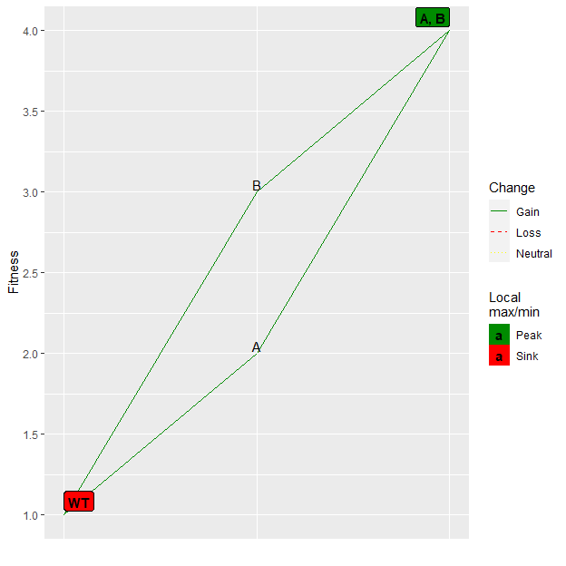

```r
plotFitnessLandscape(evalAllGenotypes(fem4))
```

You can also check what OncoSimulR thinks the fitnesses are, with the `evalAllGenotypes` function that we will use repeatedly below (of course, here we should see the same fitnesses we entered):

```r
evalAllGenotypes(fem4, addwt = TRUE)
##   Genotype Fitness
## 1       WT       1
## 2        A       2
## 3        B       3
## 4     A, B       4
```

And you can plot the fitness landscape:

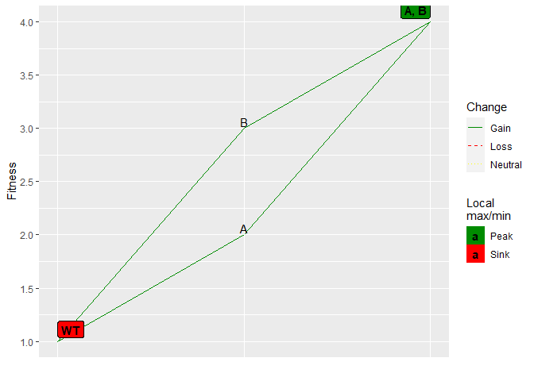

```r
plotFitnessLandscape(evalAllGenotypes(fem4))
```

To specify the mapping you can also use a matrix (or data frame) with $g + 1$ columns; each of the first $g$ columns contains a 1 or a 0 indicating that the gene of that column is mutated or not. Column $g+ 1$ contains the fitness values. And you do not even need to specify all the genotypes: the missing genotypes are assigned a fitness 0 —except for the WT genotype which, if missing, is assigned a fitness of 1:

```r
m6 <- cbind(c(1, 1), c(1, 0), c(2, 3))
fem6 <- allFitnessEffects(genotFitness = m6)
## No column names: assigning gene names from LETTERS
## Warning in to_genotFitness_std(genotFitness,
## frequencyDependentFitness = FALSE, : No wildtype in the fitness
## landscape!!! Adding it with fitness 1.
evalAllGenotypes(fem6, addwt = TRUE)
##   Genotype Fitness
## 1       WT       1
## 2        A       3
## 3        B       0
## 4     A, B       2
## plot(fem6)
```

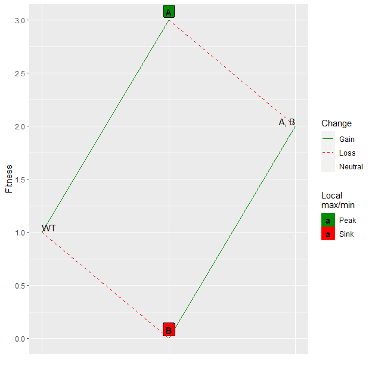

```r
plotFitnessLandscape(evalAllGenotypes(fem6))
```

This way of giving a fitness specification to OncoSimulR might be ideal if you directly generate random mappings of genotypes to fitness (or random fitness landscapes), as we will do in section 9. Specially when the fitness landscape contains many non-viable genotypes (which are considered those with fitness —birth rate— $<1e-9$) this can result in considerable savings as we only need to check the fitness of the viable genotypes in a table (a C++ map). Note, however, that using the Bozic model with the fitness landscape specification is not tested. In addition, for speed, missing genotypes from the fitness landscape specification are taken to be non-viable genotypes (**beware!! this is a breaking change relative to versions < 2.9.1**)[^6].

In the case of frequency-dependent fitness situations, the only way to specify fitness effects is using `genoFitnes` as we have shown before, but now you need to set `frequencyDependentFitness = TRUE` in `allFitnessEffects`. The fundamental difference is the Fitness column in `genoFitnes`. Now this column must be a character vector and each element (character also) is a function whose variables are the relative frequencies of the clones in the population. You must specify the variables like f_, for frequency of wild type, f_1 or f_A for frequency of mutant A or position 1, f_1_2 or f_A_B for double mutant, and so on. Mathematical operations and symbols allowed are described in the documentation of C++ library ExprTk (http://www.partow.net/programming/exprtk/). ExprTk is the library used to parse and evaluate the fitness equations. The numeric vector `spPopSizes` is only necesary to evaluate genotypes through `evalGenotype` or `evalAllGenotypes` functions because population sizes are needed to calculate the clone’s frequencies.

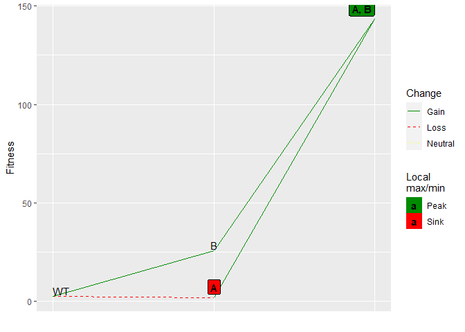

```r
r <- data.frame(Genotype = c("WT", "A", "B", "A, B"),
                 Fitness = c("10 * f_",
                             "10 * f_1",
                             "50 * f_2",
                             "200 * (f_1 + f_2) + 50 * f_1_2"))

afe <- allFitnessEffects(genotFitness = r,
                         frequencyDependentFitness = TRUE,
                         frequencyType = "rel")

plotFitnessLandscape(evalAllGenotypes(afe,
                                      spPopSizes = c(WT = 2500, A = 2000,
                                                     B = 5500, "A, B" = 700)))
```

The above example is simple enough in terms of genes and genotypes that using `f_1` is OK. But it will be better, as examples get more complex, to use:

```r
r <- data.frame(Genotype = c("WT", "A", "B", "A, B"),
                 Fitness = c("10 * f_",
                             "10 * f_A",
                             "50 * f_B",
                             "200 * (f_A + f_B) + 50 * f_A_B"))
```

which makes explicit what depends on what (i.e., you do not need to keep in mind the mapping of letters to numbers). In other words, we write `f_genotype expressed as combination of gene names`, with the gene names we are actually using. And those `f_something_other`, will match the genotypes given in `Genotype` (there will a `something, other` genotype).

### 3.1.2 How to specify fitness effects with the lego system

An alternative general approach followed in many genetic simulators is to specify how particular combinations of alleles modify the wildtype genotype or the genotype that contains the individual effects of the interacting genes (e.g., see equation 1 in the supplementary material for FFPopSim (Zanini and Neher 2012)). For example, if we specify that a mutation in “A” contributes 0.04, a mutation in “B” contributes 0.03, and the double mutation “A:B” contributes 0.1, that means that the fitness of the “A, B” genotype (the genotype with A and B mutated) is that of the wildtype (1, by default), plus (actually, times —see section 3.2— but plus on the log scale) the effects of having A mutated, plus (times) the effects of having B mutated, plus (times) the effects of “A:B” both being mutated.

We will see below that with the “lego system” it is possible to do something very similar to the explicit mapping of section 3.1.1. But this will sometimes require a more cumbersome notation (and sometimes also will require your doing some math). We will see examples in sections 3.7.1, 3.7.2 and 3.7.3 or the example in 5.4.2. But then, if we can be explicit about (at least some of) the mappings $genotype \rightarrow fitness$, how are these procedures different? When you use the “lego system” you can combine both a partial explicit mapping of genotypes to fitness with arbitrary fitness effects of other genes/modules. In other words, with the “lego system” OncoSimulR makes it simple to be explicit about the mapping of specific genotypes, while also using the “how this specific effects modifies previous effects” logic, leading to a flexible specification. This also means that in many cases the same fitness effects can be specified in several different ways.

Most of the rest of this section is devoted to explaining how to combine those pieces. Before that, however, we need to discuss the fitness model we use.

## 3.2 Numeric values of fitness effects

We evaluate fitness using the usual (Zanini and Neher 2012; Gillespie 1993; Beerenwinkel, Eriksson, and Sturmfels 2007; Datta et al. 2013) multiplicative model: fitness is $\prod (1 + s_i)$ where $s_i$ is the fitness effect of gene (or gene interaction) $i$. In all models except Bozic, this fitness refers to the growth rate (the death rate being fixed to 1[^7]). The original model of McFarland et al. (2013) has a slightly different parameterization, but you can go easily from one to the other (see section 3.2.1).

For the Bozic model (Bozic et al. 2010), however, the birth rate is set to 1, and the death rate then becomes $\prod (1 - s_i)$.

### 3.2.1 McFarland parameterization

In the original model of McFarland et al. (2013), the effects of drivers contribute to the numerator of the birth rate, and those of the (deleterious) passengers to the denominator as: $\frac{(1 + s)^d}{(1 + s_p)^p}$, where $d$ and $p$ are, respectively, the total number of drivers and passengers in a genotype, and here the fitness effects of all drivers is the same ($s$) and that of all passengers the same too ($s_p$). Note that, as written above, and as explicitly said in McFarland et al. (2013) (see p. 2911) and CD McFarland (2014) (see p. 9), “(…) $s_p$ is the fitness disadvantage conferred by a passenger”. In other words, the larger the $s_p$ the more deleterious the passenger.

This is obvious, but I make it explicit because in our parameterization a positive $s$ means fitness advantage, whereas fitness disadvantages are associated with negative $s$. Of course, if you rewrite the above expression as $\frac{(1 + s)^d}{(1 - s_p)^p}$ then we are back to the “positive means fitness advantage and negative means fitness disadvantage”.

As CD McFarland (2014) explains (see p. 9, bottom), we can rewrite the above expression so that there are no terms in the denominator. McFarland writes it as (I copy verbatim from the fourth and fifth lines from the bottom on his p. 9) $(1 + s_d)^{n_d} (1 - s_p^{'})^{n_p}$ where $s_p^{'} = s_p/(1 + s_p)$.

However, if we want to express everything as products (no ratios) and use the “positive s means advantage and negative s means disadvantage” rule, we want to write the above expression as $(1 + s_d)^{n_d} (1 + s_{pp})^{n_p}$ where $s_{pp} = -s_p/(1 + s_p)$. And this is actually what we do in v.2. There is an example, for instance, in section 6.5.2 where you will see:

```r
sp <- 1e-3
spp <- -sp/(1 + sp)
```

so we are going from the “(…) $s_p$ is the fitness disadvantage conferred by a passenger” in McFarland et al. (2013) (p. 2911) and CD McFarland (2014) (p. 9) to the expression where we have a product $\prod (1 + s_i)$, with the “positive s means advantage and negative s means disadvantage” rule. This reparameterization applies to v.2. In v.1 we used the same parameterization as in the original one in McFarland et al. (2013), but with the “positive s means advantage and negative s means disadvantage” rule (so we are using expression $\frac{(1 + s)^d}{(1 - s_p)^p}$).

#### 3.2.1.1 Death rate under the McFarland model

For death rate, we use the expression that McFarland et al. (2013) (see their p. 2911) use “(…) for large cancers (grown to $10^6$ cells)”: $D(N) = \log(1 + N/K)$ where $K$ is the initial equilibrium population size. As the authors explain, for large N/K the above expression “(…) recapitulates Gompertzian dynamics observed experimentally for large tumors”.

By default, OncoSimulR uses a value of $K=initSize/(e^{1} - 1)$ so that the starting population is at equilibrium.

A consequence of the above expression for death rate is that if the population size decreases the death rate decreases. This is not relevant in most cases (as mutations, or some mutations, will inexorably lead to population size increases). And this prevents the McFL model from resulting in extinction even with very small population sizes as long as birth rate $\ge$ death rate. (For small population sizes, it is likely that the population will become extinct if birth rate = death rate; you can try this with the exponential model).

But this is not what we want in some other models, such as frequency-dependent ones, where modeling population collapse (which will happen if birth rate < death rate) can be important (as in the example in 10.3). Here, it makes sense to set $D(N) = \max(1, \log(1 + N/K))$ so that the death rate never decreases below 1. (Using 1 is reasonable if we consider the equilibrium birth rate in the absence of any mutants to be 1). You can specify this behaviour using model `McFLD` (a shorthand for `McFarlandLogD`).

### 3.2.2 No viability of clones and types of models

For all models where fitness affects directly the birth rate (all except Bozic), if you specify that some event (say, mutating gene A) has $s_A \le -1$, if that event happens then birth rate becomes zero. This is taken to indicate that the clone is not even viable and thus disappears immediately without any chance for mutation[^8].

Models based on Bozic, however, have a birth rate of 1 and mutations affect the death rate. In this case, a death rate larger than birth rate, *per se*, does not signal immediate extinction and, moreover, even for death rates that are a few times larger than birth rates, the clone could mutate before becoming extinct[^9].

In general, if you want to identify some mutations or some combinations of mutations as leading to immediate extinction (i.e., no viability), of the affected clone, set it to $-\infty$ as this would work even if how birth rates of 0 are handled changes. Most examples below evaluate fitness by its effects on the birth rate. You can see one where we do it both ways in Section 3.11.1.

## 3.3 Genes without interactions

This is a simple scenario. Each gene $i$ has a fitness effect $s_i$ if mutated. The $s_i$ can come from any distribution you want. As an example let’s use three genes. We know there are no order effects, but we will also see what happens if we examine genotypes as ordered.

```r
ai1 <- evalAllGenotypes(allFitnessEffects(
    noIntGenes = c(0.05, -.2, .1)), order = FALSE)
```

We can easily verify the first results:

```r
ai1
##   Genotype Fitness
## 1        1   1.050
## 2        2   0.800
## 3        3   1.100
## 4     1, 2   0.840
## 5     1, 3   1.155
## 6     2, 3   0.880
## 7  1, 2, 3   0.924
```

```r
all(ai1[, "Fitness"]  == c( (1 + .05), (1 - .2), (1 + .1),
       (1 + .05) * (1 - .2),
       (1 + .05) * (1 + .1),
       (1 - .2) * (1 + .1),
       (1 + .05) * (1 - .2) * (1 + .1)))
## [1] TRUE
```

And we can see that considering the order of mutations (see section 3.6) makes no difference:

```r
(ai2 <- evalAllGenotypes(allFitnessEffects(
    noIntGenes = c(0.05, -.2, .1)), order = TRUE,
    addwt = TRUE))
##     Genotype Fitness
## 1         WT   1.000
## 2          1   1.050
## 3          2   0.800
## 4          3   1.100
## 5      1 > 2   0.840
## 6      1 > 3   1.155
## 7      2 > 1   0.840
## 8      2 > 3   0.880
## 9      3 > 1   1.155
## 10     3 > 2   0.880
## 11 1 > 2 > 3   0.924
## 12 1 > 3 > 2   0.924
## 13 2 > 1 > 3   0.924
## 14 2 > 3 > 1   0.924
## 15 3 > 1 > 2   0.924
## 16 3 > 2 > 1   0.924
```

(The meaning of the notation in the output table is as follows: “WT” denotes the wild-type, or non-mutated clone. The notation $x > y$ means that a mutation in “x” happened before a mutation in “y”. A genotype $x > y\ \_\ z$ means that a mutation in “x” happened before a mutation in “y”; there is also a mutation in “z”, but that is a gene for which order does not matter).

And what if I want genes without interactions but I want modules (see section 3.5)? Go to section 3.8.

## 3.4 Using DAGs: Restrictions in the order of mutations as extended posets

### 3.4.1 AND, OR, XOR relationships

The literature on Oncogenetic trees, CBNs, etc, has used graphs as a way of showing the restrictions in the order in which mutations can accumulate. The meaning of “convergent arrows” in these graphs, however, differs. In Figure 1 of Korsunsky et al. (2014) we are shown a simple diagram that illustrates the three basic different meanings of convergent arrows using two parental nodes. We will illustrate it here with three. Suppose we focus on node “g” in the following figure (we will create it shortly)

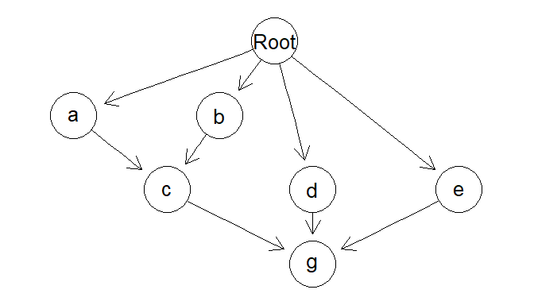

```r
data(examplesFitnessEffects)
plot(examplesFitnessEffects[["cbn1"]])
```

- In relationships of the type used in **Conjunctive Bayesian Networks (CBN)** (e.g., Gerstung et al. 2009), we are modeling an **AND** relationship, also called **CMPN** by Korsunsky et al. (2014) or **monotone** relationship by Farahani and Lagergren (2013). If the relationship in the graph is fully respected, then “g” will only appear if all of “c”, “d”, and “e” are already mutated.
- **Semimonotone** relationships *sensu* Farahani and Lagergren (2013) or **DMPN** *sensu* Korsunsky et al. (2014) are **OR** relationships: “g” will appear if one or more of “c”, “d”, or “e” are already mutated.
- **XMPN** relationships (Korsunsky et al. 2014) are **XOR** relationships: “g” will be present only if exactly one of “c”, “d”, or “e” is present.

Note that Oncogenetic trees (Desper et al. 1999; Szabo and Boucher 2008) need not deal with the above distinctions, since the DAGs are trees: no node has more than one incoming connection or more than one parent[^10].

To have a flexible way of specifying all of these restrictions, we will want to be able to say what kind of dependency each child node has on its parents.

### 3.4.2 Fitness effects

Those DAGs specify dependencies and, as explained in Diaz-Uriarte (2015), it is simple to map them to a simple evolutionary model: any set of mutations that does not conform to the restrictions encoded in the graph will have a fitness of 0. However, we might not want to require absolute compliance with the DAG. This means we might want to allow deviations from the DAG with a corresponding penalization that is, however, not identical to setting fitness to 0 (again, see Diaz-Uriarte 2015). This we can do by being explicit about the fitness effects of the deviations from the restrictions encoded in the DAG. We will use below a column of `s` for the fitness effect when the restrictions are satisfied and a column of `sh` when they are not. (See also 3.2 for the details about the meaning of the fitness effects).

That way of specifying fitness effects makes it also trivial to use the model in Hjelm, Höglund, and Lagergren (2006) where all mutations might be allowed to occur, but the presence of some mutations increases the probability of occurrence of other mutations. For example, the values of `sh` could be all small positive ones (or for mildly deleterious effects, small negative numbers), while the values of `s` are much larger positive numbers.

### 3.4.3 Extended posets

In version 1 of this package we used posets in the sense of Beerenwinkel, Eriksson, and Sturmfels (2007) and Gerstung et al. (2009), as explained in the help for `poset`. The functionality for simulating directly from such two column matrices has been removed. Instead, we use what we call extended posets.

With the extended posets, we continue using two columns, that specify parents and children, but we add columns for the specific values of fitness effects (both s and sh —i.e., fitness effects for what happens when restrictions are and are not satisfied) and for the type of dependency as explained in section 3.4.1.

We can now illustrate the specification of different fitness effects using DAGs.

### 3.4.4 DAGs: A first conjunction (AND) example

```r
cs <-  data.frame(parent = c(rep("Root", 4), "a", "b", "d", "e", "c"),
                 child = c("a", "b", "d", "e", "c", "c", rep("g", 3)),
                 s = 0.1,
                 sh = -0.9,
                 typeDep = "MN")

cbn1 <- allFitnessEffects(cs)
```

(We skip one letter, just to show that names need not be consecutive or have any particular order.)

We can get a graphical representation using the default “graphNEL”

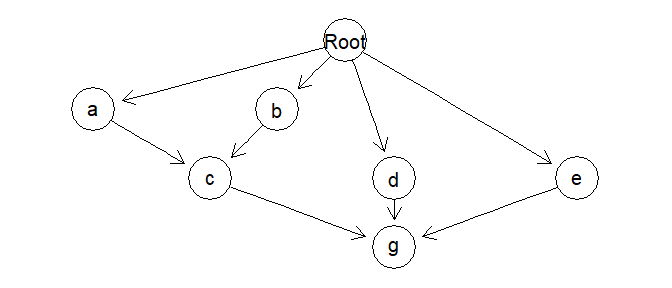

```r
plot(cbn1)
```

or one using “igraph”:

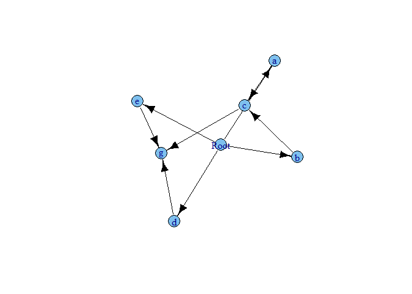

```r
plot(cbn1, "igraph")
```

Since we have a parent and children, the reingold.tilford layout is probably the best here, so you might want to use that:

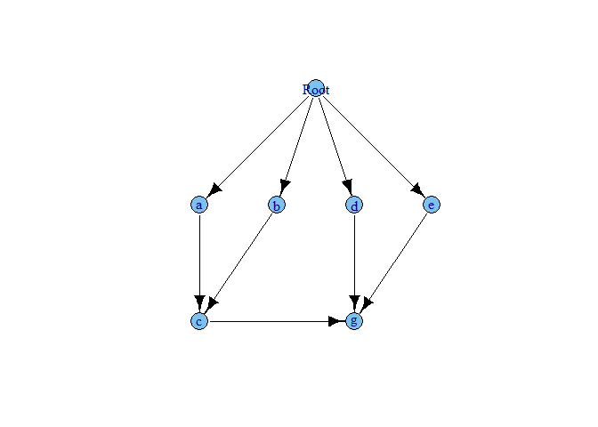

```r
library(igraph) ## to make the reingold.tilford layout available
plot(cbn1, "igraph", layout = layout.reingold.tilford)
```

And what is the fitness of all genotypes?

```r
gfs <- evalAllGenotypes(cbn1, order = FALSE, addwt = TRUE)

gfs[1:15, ]
##    Genotype Fitness
## 1        WT    1.00
## 2         a    1.10
## 3         b    1.10
## 4         c    0.10
## 5         d    1.10
## 6         e    1.10
## 7         g    0.10
## 8      a, b    1.21
## 9      a, c    0.11
## 10     a, d    1.21
## 11     a, e    1.21
## 12     a, g    0.11
## 13     b, c    0.11
## 14     b, d    1.21
## 15     b, e    1.21
```

You can verify that for each genotype, if a mutation is present without all of its dependencies present, you get a $(1 - 0.9)$ multiplier, and you get a $(1 + 0.1)$ multiplier for all the rest with its direct parents satisfied. For example, genotypes “a”, or “b”, or “d”, or “e” have fitness $(1 + 0.1)$, genotype “a, b, c” has fitness $(1 + 0.1)^3$, but genotype “a, c” has fitness $(1 + 0.1) (1 - 0.9) = 0.11$.

### 3.4.5 DAGs: A second conjunction example

Let’s try a first attempt at a somewhat more complex example, where the fitness consequences of different genes differ.

```r
c1 <- data.frame(parent = c(rep("Root", 4), "a", "b", "d", "e", "c"),
                 child = c("a", "b", "d", "e", "c", "c", rep("g", 3)),
                 s = c(0.01, 0.02, 0.03, 0.04, 0.1, 0.1, rep(0.2, 3)),
                 sh = c(rep(0, 4), c(-.1, -.2), c(-.05, -.06, -.07)),
                 typeDep = "MN")

try(fc1 <- allFitnessEffects(c1))
## Error in FUN(X[[i]], ...) : Not all sh identical within a child
```

If you try this, you’ll get an error. There is an error because the “sh” varies within a child, and we do not allow that for a poset-type specification, as it is ambiguous. If you need arbitrary fitness values for arbitrary combinations of genotypes, you can specify them using epistatic effects as in section 3.7 and order effects as in section 3.6.

Why do we need to specify as many “s” and “sh” as there are rows (or a single one, that gets expanded to those many) when the “s” and “sh” are properties of the child node, not of the edges? Because, for ease, we use a data.frame.

We fix the error in our specification. Notice that the “sh” is not set to $-1$ in these examples. If you want strict compliance with the poset restrictions, you should set $sh = -1$ or, better yet, $sh = -\infty$ (see section 3.2.2), but having an $sh > -1$ will lead to fitnesses that are $> 0$ and, thus, is a way of modeling small deviations from the poset (see discussion in Diaz-Uriarte 2015).

Note that for those nodes that depend only on “Root” the type of dependency is irrelevant.

```r
c1 <- data.frame(parent = c(rep("Root", 4), "a", "b", "d", "e", "c"),
                 child = c("a", "b", "d", "e", "c", "c", rep("g", 3)),
                 s = c(0.01, 0.02, 0.03, 0.04, 0.1, 0.1, rep(0.2, 3)),
                 sh = c(rep(0, 4), c(-.9, -.9), rep(-.95, 3)),
                 typeDep = "MN")

cbn2 <- allFitnessEffects(c1)
```

We could get graphical representations but the figures would be the same as in the example in section 3.4.4, since the structure has not changed, only the numeric values.

What is the fitness of all possible genotypes? Here, order of events *per se* does not matter, beyond that considered in the poset. In other words, the fitness of genotype “a, b, c” is the same no matter how we got to “a, b, c”. What matters is whether or not the genes on which each of “a”, “b”, and “c” depend are present or not (I only show the first 10 genotypes)

```r
gcbn2 <- evalAllGenotypes(cbn2, order = FALSE)
gcbn2[1:10, ]
##    Genotype Fitness
## 1         a  1.0100
## 2         b  1.0200
## 3         c  0.1000
## 4         d  1.0300
## 5         e  1.0400
## 6         g  0.0500
## 7      a, b  1.0302
## 8      a, c  0.1010
## 9      a, d  1.0403
## 10     a, e  1.0504
```

Of course, if we were to look at genotypes but taking into account order of occurrence of mutations, we would see no differences

```r
gcbn2o <- evalAllGenotypes(cbn2, order = TRUE, max = 1956)
gcbn2o[1:10, ]
##    Genotype Fitness
## 1         a  1.0100
## 2         b  1.0200
## 3         c  0.1000
## 4         d  1.0300
## 5         e  1.0400
## 6         g  0.0500
## 7     a > b  1.0302
## 8     a > c  0.1010
## 9     a > d  1.0403
## 10    a > e  1.0504
```

(The $max = 1956$ is there so that we show all the genotypes, even if they are more than 256, the default.)

You can check the output and verify things are as they should. For instance:

```r
all.equal(
        gcbn2[c(1:21, 22, 28, 41, 44, 56, 63 ) , "Fitness"],
        c(1.01, 1.02, 0.1, 1.03, 1.04, 0.05,
          1.01 * c(1.02, 0.1, 1.03, 1.04, 0.05),
          1.02 * c(0.10, 1.03, 1.04, 0.05),
          0.1 * c(1.03, 1.04, 0.05),
          1.03 * c(1.04, 0.05),
          1.04 * 0.05,
          1.01 * 1.02 * 1.1,
          1.01 * 0.1 * 0.05,
          1.03 * 1.04 * 0.05,
          1.01 * 1.02 * 1.1 * 0.05,
          1.03 * 1.04 * 1.2 * 0.1, ## notice this
          1.01 * 1.02 * 1.03 * 1.04 * 1.1 * 1.2
          ))
## [1] TRUE
```

A particular one that is important to understand is genotype with mutated genes “c, d, e, g”:

```r
gcbn2[56, ]
##      Genotype  Fitness
## 56 c, d, e, g 0.128544
all.equal(gcbn2[56, "Fitness"], 1.03 * 1.04 * 1.2 * 0.10)
## [1] TRUE
```

### 3.4.6 DAGs: A semimonotone or “OR” example

We will reuse the above example, changing the type of relationship:

```r
s1 <- data.frame(parent = c(rep("Root", 4), "a", "b", "d", "e", "c"),
                 child = c("a", "b", "d", "e", "c", "c", rep("g", 3)),
                 s = c(0.01, 0.02, 0.03, 0.04, 0.1, 0.1, rep(0.2, 3)),
                 sh = c(rep(0, 4), c(-.9, -.9), rep(-.95, 3)),
                 typeDep = "SM")

smn1 <- allFitnessEffects(s1)
```

It looks like this (where edges are shown in blue to denote the semimonotone relationship):

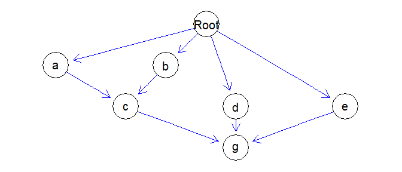

```r
plot(smn1)
```

```r
gsmn1 <- evalAllGenotypes(smn1, order = FALSE)
```

Having just one parental dependency satisfied is now enough, in contrast to what happened before. For instance:

```r
gcbn2[c(8, 12, 22), ]
##    Genotype Fitness
## 8      a, c 0.10100
## 12     b, c 0.10200
## 22  a, b, c 1.13322
gsmn1[c(8, 12, 22), ]
##    Genotype Fitness
## 8      a, c 1.11100
## 12     b, c 1.12200
## 22  a, b, c 1.13322

gcbn2[c(20:21, 28), ]
##    Genotype Fitness
## 20     d, g 0.05150
## 21     e, g 0.05200
## 28  a, c, g 0.00505
gsmn1[c(20:21, 28), ]
##    Genotype Fitness
## 20     d, g  1.2360
## 21     e, g  1.2480
## 28  a, c, g  1.3332
```

### 3.4.7 An “XMPN” or “XOR” example

Again, we reuse the example above, changing the type of relationship:

```r
x1 <- data.frame(parent = c(rep("Root", 4), "a", "b", "d", "e", "c"),
                 child = c("a", "b", "d", "e", "c", "c", rep("g", 3)),
                 s = c(0.01, 0.02, 0.03, 0.04, 0.1, 0.1, rep(0.2, 3)),
                 sh = c(rep(0, 4), c(-.9, -.9), rep(-.95, 3)),
                 typeDep = "XMPN")

xor1 <- allFitnessEffects(x1)
```

It looks like this (edges in red to denote the “XOR” relationship):

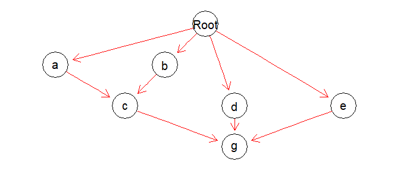

```r
plot(xor1)
```

```r
gxor1 <- evalAllGenotypes(xor1, order = FALSE)
```

```r
gxor1[c(22, 41), ]
##    Genotype Fitness
## 22  a, b, c 0.10302
## 41  d, e, g 0.05356
c(1.01 * 1.02 * 0.1, 1.03 * 1.04 * 0.05)
## [1] 0.10302 0.05356
```

However, having just both “a” and “b” is identical to the case with CBN and the monotone relationship (see sections 3.4.5 and 3.4.6). If you want the joint presence of “a” and “b” to result in different fitness than the product of the individual terms, without considering the presence of “c”, you can specify that using general epistatic effects (section 3.7).

We also see a very different pattern compared to CBN (section 3.4.5) here:

```r
gxor1[28, ]
##    Genotype Fitness
## 28  a, c, g  1.3332
1.01 * 1.1 * 1.2
## [1] 1.3332
```

as exactly one of the dependencies for both “c” and “g” are satisfied.

But

```r
gxor1[44, ]
##      Genotype  Fitness
## 44 a, b, c, g 0.123624
1.01 * 1.02 * 0.1 * 1.2
## [1] 0.123624
```

is the result of a $0.1$ for “c” (and a $1.2$ for “g” that has exactly one of its dependencies satisfied).

### 3.4.8 Posets: the three types of relationships

```r
p3 <- data.frame(
    parent = c(rep("Root", 4), "a", "b", "d", "e", "c", "f"),
    child = c("a", "b", "d", "e", "c", "c", "f", "f", "g", "g"),
    s = c(0.01, 0.02, 0.03, 0.04, 0.1, 0.1, 0.2, 0.2, 0.3, 0.3),
    sh = c(rep(0, 4), c(-.9, -.9), c(-.95, -.95), c(-.99, -.99)),
    typeDep = c(rep("--", 4),
                "XMPN", "XMPN", "MN", "MN", "SM", "SM"))
fp3 <- allFitnessEffects(p3)
```

This is how it looks like:

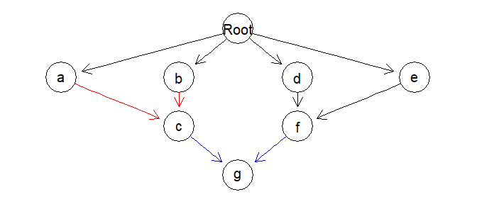

```r
plot(fp3)
```

We can also use “igraph”:

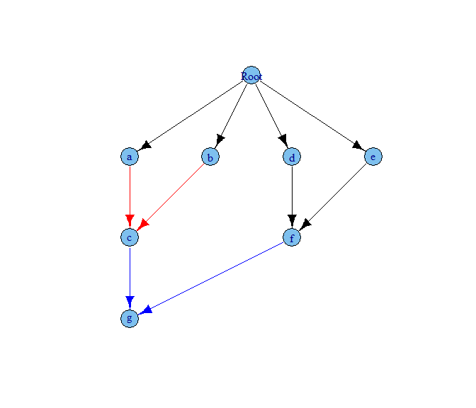

```r
plot(fp3, "igraph", layout.reingold.tilford)
```

```r
gfp3 <- evalAllGenotypes(fp3, order = FALSE)
```

Let’s look at a few:

```r
gfp3[c(9, 24, 29, 59, 60, 66, 119, 120, 126, 127), ]
##                Genotype   Fitness
## 9                  a, c 1.1110000
## 24                 d, f 0.0515000
## 29              a, b, c 0.1030200
## 59              c, f, g 0.0065000
## 60              d, e, f 1.2854400
## 66           a, b, c, f 0.0051510
## 119       c, d, e, f, g 0.1671072
## 120    a, b, c, d, e, f 0.1324260
## 126    b, c, d, e, f, g 1.8749428
## 127 a, b, c, d, e, f, g 0.1721538

c(1.01 * 1.1, 1.03 * .05, 1.01 * 1.02 * 0.1, 0.1 * 0.05 * 1.3,
  1.03 * 1.04 * 1.2, 1.01 * 1.02 * 0.1 * 0.05,
  0.1 * 1.03 * 1.04 * 1.2 * 1.3,
  1.01 * 1.02 * 0.1 * 1.03 * 1.04 * 1.2,
  1.02 * 1.1 * 1.03 * 1.04 * 1.2 * 1.3,
  1.01 * 1.02 * 1.03 * 1.04 * 0.1 * 1.2 * 1.3)
##  [1] 1.1110000 0.0515000 0.1030200 0.0065000 1.2854400 0.0051510
##  [7] 0.1671072 0.1324260 1.8749428 0.1721538
```

As before, looking at the order of mutations makes no difference (look at the test directory to see a test that verifies this assertion).

## 3.5 Modules

As already mentioned, we can think of all the effects of fitness in terms not of individual genes but, rather, modules. This idea is discussed in, for example, Raphael and Vandin (2015), Gerstung et al. (2011): the restrictions encoded in, say, the DAGs can be considered to apply not to genes, but to modules, where each module is a set of genes (and the intersection between modules is the empty set). Modules, then, play the role of a “union operation” over sets of genes. Of course, if we can use modules for the restrictions in the DAGs we should also be able to use them for epistasis and order effects, as we will see later (e.g., 3.6.2).

### 3.5.1 What does a module provide

Modules can provide very compact ways of specifying relationships when you want to, well, model the existence of modules. For simplicity suppose there is a module, “A”, made of genes “a1” and “a2”, and a module “B”, made of a single gene “b1”. Module “B” can mutate if module “A” is mutated, but mutating both “a1” and “a2” provides no additional fitness advantage compared to mutating only a single one of them. We can specify this as:

```r
s <- 0.2
sboth <- (1/(1 + s)) - 1
m0 <- allFitnessEffects(data.frame(
    parent = c("Root", "Root", "a1", "a2"),
    child = c("a1", "a2", "b", "b"),
    s = s,
    sh = -1,
    typeDep = "OR"),
                        epistasis = c("a1:a2" = sboth))
evalAllGenotypes(m0, order = FALSE, addwt = TRUE)
##    Genotype Fitness
## 1        WT    1.00
## 2        a1    1.20
## 3        a2    1.20
## 4         b    0.00
## 5    a1, a2    1.20
## 6     a1, b    1.44
## 7     a2, b    1.44
## 8 a1, a2, b    1.44
```

Note that we need to add an epistasis term, with value “sboth” to capture the idea of “mutating both”a1" and “a2” provides no additional fitness advantage compared to mutating only a single one of them"; see details in section 3.7.

Now, specify it using modules:

```r
s <- 0.2
m1 <- allFitnessEffects(data.frame(
    parent = c("Root", "A"),
    child = c("A", "B"),
    s = s,
    sh = -1,
    typeDep = "OR"),
                        geneToModule = c("Root" = "Root",
                                         "A" = "a1, a2",
                                         "B" = "b1"))
evalAllGenotypes(m1, order = FALSE, addwt = TRUE)
##     Genotype Fitness
## 1         WT    1.00
## 2         a1    1.20
## 3         a2    1.20
## 4         b1    0.00
## 5     a1, a2    1.20
## 6     a1, b1    1.44
## 7     a2, b1    1.44
## 8 a1, a2, b1    1.44
```

This captures the ideas directly. The typing savings here are small, but they can be large with modules with many genes.

### 3.5.2 Specifying modules

How do you specify modules? The general procedure is simple: you pass a vector that makes explicit the mapping from modules to sets of genes. We just saw an example. There are several additional examples such as 3.5.3, 3.6.2, 3.7.4.

It is important to note that, once you specify modules, we expect all of the relationships (except those that involve the non interacting genes) to be specified as modules. Thus, all elements of the epistasis, posets (the DAGs) and order effects components should be specified in terms of modules. But you can, of course, specify a module as containing a single gene (and a single gene with the same name as the module).

What about the “Root” node? If you use a “restriction table”, that restriction table (that DAG) must have a node named “Root” and in the mapping of genes to module there **must** be a first entry that has a module and gene named “Root”, as we saw above with `geneToModule = c("Root" = "Root", ...`. We force you to do this to be explicit about the “Root” node. This is not needed (thought it does not hurt) with other fitness specifications. For instance, if we have a model with two modules, one of them with two genes (see details in section 3.8) we do not need to pass a “Root” as in

```r
fnme <- allFitnessEffects(epistasis = c("A" = 0.1,
                                        "B" = 0.2),
                          geneToModule = c("A" = "a1, a2",
                                           "B" = "b1"))
evalAllGenotypes(fnme, order = FALSE, addwt = TRUE)
##     Genotype Fitness
## 1         WT    1.00
## 2         a1    1.10
## 3         a2    1.10
## 4         b1    1.20
## 5     a1, a2    1.10
## 6     a1, b1    1.32
## 7     a2, b1    1.32
## 8 a1, a2, b1    1.32
```

but it is also OK to have a “Root” in the `geneToModule`:

```r
fnme2 <- allFitnessEffects(epistasis = c("A" = 0.1,
                                        "B" = 0.2),
                          geneToModule = c(
                              "Root" = "Root",
                              "A" = "a1, a2",
                              "B" = "b1"))
evalAllGenotypes(fnme, order = FALSE, addwt = TRUE)
##     Genotype Fitness
## 1         WT    1.00
## 2         a1    1.10
## 3         a2    1.10
## 4         b1    1.20
## 5     a1, a2    1.10
## 6     a1, b1    1.32
## 7     a2, b1    1.32
## 8 a1, a2, b1    1.32
```

### 3.5.3 Modules and posets again: the three types of relationships and modules

We use the same specification of poset, but add modules. To keep it manageable, we only add a few genes for some modules, and have some modules with a single gene. Beware that the number of genotypes is starting to grow quite fast, though. We capitalize to differentiate modules (capital letters) from genes (lowercase with a number), but this is not needed.

```r
p4 <- data.frame(
    parent = c(rep("Root", 4), "A", "B", "D", "E", "C", "F"),
    child = c("A", "B", "D", "E", "C", "C", "F", "F", "G", "G"),
    s = c(0.01, 0.02, 0.03, 0.04, 0.1, 0.1, 0.2, 0.2, 0.3, 0.3),
    sh = c(rep(0, 4), c(-.9, -.9), c(-.95, -.95), c(-.99, -.99)),
    typeDep = c(rep("--", 4),
                "XMPN", "XMPN", "MN", "MN", "SM", "SM"))

fp4m <- allFitnessEffects(
    p4,
    geneToModule = c("Root" = "Root", "A" = "a1",
                     "B" = "b1, b2", "C" = "c1",
                     "D" = "d1, d2", "E" = "e1",
                     "F" = "f1, f2", "G" = "g1"))
```

By default, plotting shows the modules:

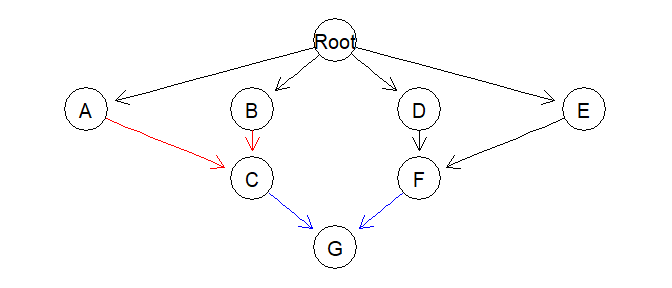

```r
plot(fp4m)
```

but we can show the gene names instead of the module names:

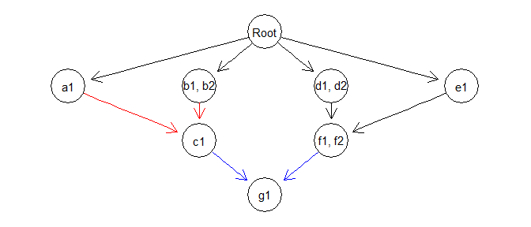

```r
plot(fp4m, expandModules = TRUE)
```

or

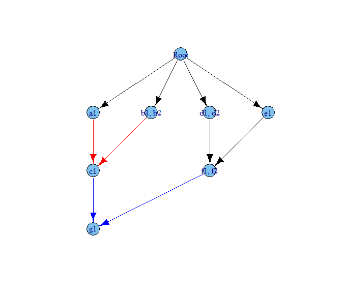

```r
plot(fp4m, "igraph", layout = layout.reingold.tilford,
     expandModules = TRUE)
```

We obtain the fitness of all genotypes in the usual way:

```r
gfp4 <- evalAllGenotypes(fp4m, order = FALSE, max = 1024)
```

Let’s look at a few of those:

```r
gfp4[c(12, 20, 21, 40, 41, 46, 50, 55, 64, 92,
       155, 157, 163, 372, 632, 828), ]
##                   Genotype  Fitness
## 12                  a1, b2 1.030200
## 20                  b1, b2 1.020000
## 21                  b1, c1 1.122000
## 40                  c1, g1 0.130000
## 41                  d1, d2 1.030000
## 46                  d2, e1 1.071200
## 50                  e1, f1 0.052000
## 55                  f2, g1 0.065000
## 64              a1, b2, c1 0.103020
## 92              b1, b2, c1 1.122000
## 155             c1, f2, g1 0.006500
## 157             d1, d2, f1 0.051500
## 163             d1, f1, f2 0.051500
## 372         d1, d2, e1, f2 1.285440
## 632     d1, d2, e1, f1, f2 1.285440
## 828 b2, c1, d1, e1, f2, g1 1.874943

c(1.01 * 1.02, 1.02, 1.02 * 1.1, 0.1 * 1.3, 1.03,
  1.03 * 1.04, 1.04 * 0.05, 0.05 * 1.3,
  1.01 * 1.02 * 0.1, 1.02 * 1.1, 0.1 * 0.05 * 1.3,
  1.03 * 0.05, 1.03 * 0.05, 1.03 * 1.04 * 1.2, 1.03 * 1.04 * 1.2,
  1.02 * 1.1 * 1.03 * 1.04 * 1.2 * 1.3)
##  [1] 1.030200 1.020000 1.122000 0.130000 1.030000 1.071200 0.052000
##  [8] 0.065000 0.103020 1.122000 0.006500 0.051500 0.051500 1.285440
## [15] 1.285440 1.874943
```

## 3.6 Order effects

As explained in the introduction (section 1), by order effects we mean a phenomenon such as the one shown empirically by Ortmann et al. (2015): the fitness of a double mutant “A”, “B” is different depending on whether “A” was acquired before “B” or “B” before “A”. This, of course, can be generalized to more than two genes.

Note that order effects are different from the restrictions in the order of accumulation of mutations discussed in section 3.4. With restrictions in the order of accumulation of mutations we might say that acquiring “B” depends or is facilitated by having “A” mutated (and, unless we allowed for multiple mutations, having “A” mutated means having “A” mutated before “B”). However, once you have the genotype “A, B”, its fitness does not depend on the order in which “A” and “B” appeared.

### 3.6.1 Order effects: three-gene orders

Consider this case, where three specific three-gene orders and two two-gene orders (one of them a subset of one of the three) lead to different fitness compared to the wild-type. We add also modules, to show its usage (but just limit ourselves to using one gene per module here).

Order effects are specified using a $x > y$, which means that that order effect is satisfied when module $x$ is mutated before module $y$.

```r
o3 <- allFitnessEffects(orderEffects = c(
                            "F > D > M" = -0.3,
                            "D > F > M" = 0.4,
                            "D > M > F" = 0.2,
                            "D > M"     = 0.1,
                            "M > D"     = 0.5),
                        geneToModule =
                            c("M" = "m",
                              "F" = "f",
                              "D" = "d") )


(ag <- evalAllGenotypes(o3, addwt = TRUE, order = TRUE))
##     Genotype Fitness
## 1         WT    1.00
## 2          d    1.00
## 3          f    1.00
## 4          m    1.00
## 5      d > f    1.00
## 6      d > m    1.10
## 7      f > d    1.00
## 8      f > m    1.00
## 9      m > d    1.50
## 10     m > f    1.00
## 11 d > f > m    1.54
## 12 d > m > f    1.32
## 13 f > d > m    0.77
## 14 f > m > d    1.50
## 15 m > d > f    1.50
## 16 m > f > d    1.50
```

(The meaning of the notation in the output table is as follows: “WT” denotes the wild-type, or non-mutated clone. The notation $x > y$ means that a mutation in “x” happened before a mutation in “y”. A genotype $x > y\ \_\ z$ means that a mutation in “x” happened before a mutation in “y”; there is also a mutation in “z”, but that is a gene for which order does not matter).

### 3.6.2 Order effects and modules with multiple genes

Consider the following case:

```r
ofe1 <- allFitnessEffects(
    orderEffects = c("F > D" = -0.3, "D > F" = 0.4),
    geneToModule =
        c("F" = "f1, f2",
          "D" = "d1, d2") )

ag <- evalAllGenotypes(ofe1, order = TRUE)
```

There are four genes, $d1, d2, f1, f2$, where each $d$ belongs to module $D$ and each $f$ belongs to module $F$.

What to expect for cases such as $d1 > f1$ or $f1 > d1$ is clear, as shown in

```r
ag[5:16,]
##    Genotype Fitness
## 5   d1 > d2     1.0
## 6   d1 > f1     1.4
## 7   d1 > f2     1.4
## 8   d2 > d1     1.0
## 9   d2 > f1     1.4
## 10  d2 > f2     1.4
## 11  f1 > d1     0.7
## 12  f1 > d2     0.7
## 13  f1 > f2     1.0
## 14  f2 > d1     0.7
## 15  f2 > d2     0.7
## 16  f2 > f1     1.0
```

Likewise, cases such as $d1 > d2 > f1$ or $f2 > f1 > d1$ are clear, because in terms of modules they map to $ D > F$ or $F > D$: the observed order of mutation $d1 > d2 > f1$ means that module $D$ was mutated first and module $F$ was mutated second. Similar for $d1 > f1 > f2$ or $f1 > d1 > d2$: those map to $D > F$ and $F > D$. We can see the fitness of those four case in:

```r
ag[c(17, 39, 19, 29), ]
##        Genotype Fitness
## 17 d1 > d2 > f1     1.4
## 39 f2 > f1 > d1     0.7
## 19 d1 > f1 > d2     1.4
## 29 f1 > d1 > d2     0.7
```

and they correspond to the values of those order effects, where $F > D = (1 - 0.3)$ and $D > F = (1 + 0.4)$:

```r
ag[c(17, 39, 19, 29), "Fitness"] == c(1.4, 0.7, 1.4, 0.7)
## [1] TRUE TRUE TRUE TRUE
```

What if we match several patterns? For example, $d1 > f1 > d2 > f2$ and $d1 > f1 > f2 > d2$? The first maps to $D > F > D > F$ and the second to $D > F > D$. But since we are concerned with which one happened first and which happened second we should expect those two to correspond to the same fitness, that of pattern $D > F$, as is the case:

```r
ag[c(43, 44),]
##             Genotype Fitness
## 43 d1 > f1 > d2 > f2     1.4
## 44 d1 > f1 > f2 > d2     1.4
ag[c(43, 44), "Fitness"] == c(1.4, 1.4)
## [1] TRUE TRUE
```

More generally, that applies to all the patterns that start with one of the “d” genes:

```r
all(ag[41:52, "Fitness"] == 1.4)
## [1] TRUE
```

Similar arguments apply to the opposite pattern, $F > D$, which apply to all the possible gene mutation orders that start with one of the “f” genes. For example:

```r
all(ag[53:64, "Fitness"] == 0.7)
## [1] TRUE
```

### 3.6.3 Order and modules with 325 genotypes

We can of course have more than two genes per module. This just repeats the above, with five genes (there are 325 genotypes, and that is why we pass the “max” argument to `evalAllGenotypes`, to allow for more than the default 256).

```r
ofe2 <- allFitnessEffects(
    orderEffects = c("F > D" = -0.3, "D > F" = 0.4),
    geneToModule =
        c("F" = "f1, f2, f3",
          "D" = "d1, d2") )
ag2 <- evalAllGenotypes(ofe2, max = 325, order = TRUE)
```

We can verify that any combination that starts with a “d” gene and then contains at least one “f” gene will have a fitness of $1+0.4$. And any combination that starts with an “f” gene and contains at least one “d” genes will have a fitness of $1 - 0.3$. All other genotypes have a fitness of 1:

```r
all(ag2[grep("^d.*f.*", ag2[, 1]), "Fitness"] == 1.4)
## [1] TRUE
all(ag2[grep("^f.*d.*", ag2[, 1]), "Fitness"] == 0.7)
## [1] TRUE
oe <- c(grep("^f.*d.*", ag2[, 1]), grep("^d.*f.*", ag2[, 1]))
all(ag2[-oe, "Fitness"] == 1)
## [1] TRUE
```

### 3.6.4 Order effects and genes without interactions

```r
foi1 <- allFitnessEffects(
    orderEffects = c("D>B" = -0.2, "B > D" = 0.3),
    noIntGenes = c("A" = 0.05, "C" = -.2, "E" = .1))
```

You can get a verbose view of what the gene names and modules are (and their automatically created numeric codes) by:

```r
foi1[c("geneModule", "long.geneNoInt")]
## $geneModule
##   Gene Module GeneNumID ModuleNumID
## 1 Root   Root         0           0
## 2    B      B         1           1
## 3    D      D         2           2
##
## $long.geneNoInt
##   Gene GeneNumID     s
## A    A         3  0.05
## C    C         4 -0.20
## E    E         5  0.10
```

We can get the fitness of all genotypes (we set $max = 325$ because that is the number of possible genotypes):

```r
agoi1 <- evalAllGenotypes(foi1,  max = 325, order = TRUE)
head(agoi1)
##   Genotype Fitness
## 1        B    1.00
## 2        D    1.00
## 3        A    1.05
## 4        C    0.80
## 5        E    1.10
## 6    B > D    1.30
```

Now:

```r
rn <- 1:nrow(agoi1)
names(rn) <- agoi1[, 1]

agoi1[rn[LETTERS[1:5]], "Fitness"] == c(1.05, 1, 0.8, 1, 1.1)
## [1] TRUE TRUE TRUE TRUE TRUE
```

According to the fitness effects we have specified, we also know that any genotype with only two mutations, one of which is either “A”, “C” “E” and the other is “B” or “D” will have the fitness corresponding to “A”, “C” or “E”, respectively:

```r
agoi1[grep("^A > [BD]$", names(rn)), "Fitness"] == 1.05
## [1] TRUE TRUE
agoi1[grep("^C > [BD]$", names(rn)), "Fitness"] == 0.8
## [1] TRUE TRUE
agoi1[grep("^E > [BD]$", names(rn)), "Fitness"] == 1.1
## [1] TRUE TRUE
agoi1[grep("^[BD] > A$", names(rn)), "Fitness"] == 1.05
## [1] TRUE TRUE
agoi1[grep("^[BD] > C$", names(rn)), "Fitness"] == 0.8
## [1] TRUE TRUE
agoi1[grep("^[BD] > E$", names(rn)), "Fitness"] == 1.1
## [1] TRUE TRUE
```

```r
all.equal(agoi1[230:253, "Fitness"] ,
          rep((1 - 0.2) * 1.05 * 0.8 * 1.1, 24))
## [1] TRUE
```

and that will also be the value of any genotype with the five mutations where “D” comes before “B” such as those in rows 260 to 265, 277, or 322 and 323, but it will be equal to $(1 + 0.3) * 1.05 * 0.8 * 1.1 = 1.2012$ in those where “B” comes before “D”. Analogous arguments apply to four, three, and two mutation genotypes.

## 3.7 Epistasis

### 3.7.1 Epistasis: two alternative specifications

We want the following mapping of genotypes to fitness:

| A | B | Fitness |
| --- | --- | --- |
| wt | wt | 1 |
| wt | M | $1 + s_b$ |
| M | wt | $1 + s_a$ |
| M | M | $1 + s_{ab}$ |

Suppose that the actual numerical values are $s_a = 0.2, s_b = 0.3, s_{ab} = 0.7$.

We specify the above as follows:

```r
sa <- 0.2
sb <- 0.3
sab <- 0.7

e2 <- allFitnessEffects(epistasis =
                            c("A: -B" = sa,
                              "-A:B" = sb,
                              "A : B" = sab))
evalAllGenotypes(e2, order = FALSE, addwt = TRUE)
##   Genotype Fitness
## 1       WT     1.0
## 2        A     1.2
## 3        B     1.3
## 4     A, B     1.7
```

That uses the “-” specification, so we explicitly exclude some patterns: with “A:-B” we say “A when there is no B”.

But we can also use a specification where we do not use the “-”. That requires a different numerical value of the interaction, because now, as we are rewriting the interaction term as genotype “A is mutant, B is mutant” the double mutant will incorporate the effects of “A mutant”, “B mutant” and “both A and B mutants”. We can define a new $s_2$ that satisfies $(1 + s_{ab}) = (1 + s_a) (1 + s_b) (1 + s_2)$ so $(1 + s_2) = (1 + s_{ab})/((1 + s_a) (1 + s_b))$ and therefore specify as:

```r
s2 <- ((1 + sab)/((1 + sa) * (1 + sb))) - 1

e3 <- allFitnessEffects(epistasis =
                            c("A" = sa,
                              "B" = sb,
                              "A : B" = s2))
evalAllGenotypes(e3, order = FALSE, addwt = TRUE)
##   Genotype Fitness
## 1       WT     1.0
## 2        A     1.2
## 3        B     1.3
## 4     A, B     1.7
```

Note that this is the way you would specify effects with FFPopsim (Zanini and Neher 2012). Whether this specification or the previous one with “-” is simpler will depend on the model. For synthetic mortality and viability, I think the one using “-” is simpler to map genotype tables to fitness effects. See also section 3.7.2 and 3.7.3 and the example in section 5.4.2.

Finally, note that we can also specify some of these effects by combining the graph and the epistasis, as shown in section 5.2.1 or 5.4.2.

### 3.7.2 Epistasis with three genes and two alternative specifications

Suppose we have

| A | B | C | Fitness |
| --- | --- | --- | --- |
| M | wt | wt | $1 + s_a$ |
| wt | M | wt | $1 + s_b$ |
| wt | wt | M | $1 + s_c$ |
| M | M | wt | $1 + s_{ab}$ |
| wt | M | M | $1 + s_{bc}$ |
| M | wt | M | $(1 + s_a) (1 + s_c)$ |
| M | M | M | $1 + s_{abc}$ |

where missing rows have a fitness of 1 (they have been deleted for conciseness). Note that the mutant for exactly A and C has a fitness that is the product of the individual terms (so there is no epistasis in that case).

```r
sa <- 0.1
sb <- 0.15
sc <- 0.2
sab <- 0.3
sbc <- -0.25
sabc <- 0.4

sac <- (1 + sa) * (1 + sc) - 1

E3A <- allFitnessEffects(epistasis =
                            c("A:-B:-C" = sa,
                              "-A:B:-C" = sb,
                              "-A:-B:C" = sc,
                              "A:B:-C" = sab,
                              "-A:B:C" = sbc,
                              "A:-B:C" = sac,
                              "A : B : C" = sabc)
                                                )

evalAllGenotypes(E3A, order = FALSE, addwt = FALSE)
##   Genotype Fitness
## 1        A    1.10
## 2        B    1.15
## 3        C    1.20
## 4     A, B    1.30
## 5     A, C    1.32
## 6     B, C    0.75
## 7  A, B, C    1.40
```

We needed to pass the $s_{ac}$ coefficient explicitly, even if it that term was just the product. We can try to avoid using the “-”, however (but we will need to do other calculations). For simplicity, I use capital “S” in what follows where the letters differ from the previous specification:

```r
sa <- 0.1
sb <- 0.15
sc <- 0.2
sab <- 0.3
Sab <- ( (1 + sab)/((1 + sa) * (1 + sb))) - 1
Sbc <- ( (1 + sbc)/((1 + sb) * (1 + sc))) - 1
Sabc <- ( (1 + sabc)/
          ( (1 + sa) * (1 + sb) * (1 + sc) *
            (1 + Sab) * (1 + Sbc) ) ) - 1

E3B <- allFitnessEffects(epistasis =
                             c("A" = sa,
                               "B" = sb,
                               "C" = sc,
                               "A:B" = Sab,
                               "B:C" = Sbc,
                               ## "A:C" = sac, ## not needed now
                               "A : B : C" = Sabc)
                                                )
evalAllGenotypes(E3B, order = FALSE, addwt = FALSE)
##   Genotype Fitness
## 1        A    1.10
## 2        B    1.15
## 3        C    1.20
## 4     A, B    1.30
## 5     A, C    1.32
## 6     B, C    0.75
## 7  A, B, C    1.40
```

The above two are, of course, identical:

```r
all(evalAllGenotypes(E3A, order = FALSE, addwt = FALSE) ==
    evalAllGenotypes(E3B, order = FALSE, addwt = FALSE))
## [1] TRUE
```

We avoid specifying the “A:C”, as it just follows from the individual “A” and “C” terms, but given a specified genotype table, we need to do a little bit of addition and multiplication to get the coefficients.

### 3.7.3 Why can we specify some effects with a “-”?

Let’s suppose we want to specify the synthetic viability example seen before:

| A | B | Fitness |
| --- | --- | --- |
| wt | wt | 1 |
| wt | M | 0 |
| M | wt | 0 |
| M | M | (1 + s) |

where “wt” denotes wild type and “M” denotes mutant.

If you want to directly map the above table to the fitness table for the program, to specify the genotype “A is wt, B is a mutant” you can specify it as “-A,B”, not just as “B”. Why? Because just the presence of a “B” is also compatible with genotype “A is mutant and B is mutant”. If you use “-” you are explicitly saying what should not be there so that “-A,B” is NOT compatible with “A, B”. Otherwise, you need to carefully add coefficients. Depending on what you are trying to model, different specifications might be simpler. See the examples in section 3.7.1 and 3.7.2. You have both options.

### 3.7.4 Epistasis: modules

There is nothing conceptually new, but we will show an example here:

```r
sa <- 0.2
sb <- 0.3
sab <- 0.7

em <- allFitnessEffects(epistasis =
                            c("A: -B" = sa,
                              "-A:B" = sb,
                              "A : B" = sab),
                        geneToModule = c("A" = "a1, a2",
                                         "B" = "b1, b2"))
evalAllGenotypes(em, order = FALSE, addwt = TRUE)
##          Genotype Fitness
## 1              WT     1.0
## 2              a1     1.2
## 3              a2     1.2
## 4              b1     1.3
## 5              b2     1.3
## 6          a1, a2     1.2
## 7          a1, b1     1.7
## 8          a1, b2     1.7
## 9          a2, b1     1.7
## 10         a2, b2     1.7
## 11         b1, b2     1.3
## 12     a1, a2, b1     1.7
## 13     a1, a2, b2     1.7
## 14     a1, b1, b2     1.7
## 15     a2, b1, b2     1.7
## 16 a1, a2, b1, b2     1.7
```

Of course, we can do the same thing without using the “-”, as in section 3.7.1:

```r
s2 <- ((1 + sab)/((1 + sa) * (1 + sb))) - 1

em2 <- allFitnessEffects(epistasis =
                            c("A" = sa,
                              "B" = sb,
                              "A : B" = s2),
                         geneToModule = c("A" = "a1, a2",
                                         "B" = "b1, b2")
                         )
evalAllGenotypes(em2, order = FALSE, addwt = TRUE)
##          Genotype Fitness
## 1              WT     1.0
## 2              a1     1.2
## 3              a2     1.2
## 4              b1     1.3
## 5              b2     1.3
## 6          a1, a2     1.2
## 7          a1, b1     1.7
## 8          a1, b2     1.7
## 9          a2, b1     1.7
## 10         a2, b2     1.7
## 11         b1, b2     1.3
## 12     a1, a2, b1     1.7
## 13     a1, a2, b2     1.7
## 14     a1, b1, b2     1.7
## 15     a2, b1, b2     1.7
## 16 a1, a2, b1, b2     1.7
```

## 3.8 I do not want epistasis, but I want modules!

Sometimes you might want something like having several modules, say “A” and “B”, each with a number of genes, but with “A” and “B” showing no interaction.

It is a terminological issue whether we should allow `noIntGenes` (no interaction genes), as explained in section 3.3 to actually be modules. The reasoning for not allowing them is that the situation depicted above (several genes in module A, for example) actually is one of interaction: the members of “A” are combined using an “OR” operator (i.e., the fitness consequences of having one or more genes of A mutated are the same), not just simply multiplying their fitness; similarly for “B”. This is why no interaction genes also mean no modules allowed.

So how do you get what you want in this case? Enter the names of the modules in the `epistasis` component but have no term for “:” (the colon). Let’s see an example:

```r
fnme <- allFitnessEffects(epistasis = c("A" = 0.1,
                                        "B" = 0.2),
                          geneToModule = c("A" = "a1, a2",
                                           "B" = "b1, b2, b3"))

evalAllGenotypes(fnme, order = FALSE, addwt = TRUE)
##              Genotype Fitness
## 1                  WT    1.00
## 2                  a1    1.10
## 3                  a2    1.10
## 4                  b1    1.20
## 5                  b2    1.20
## 6                  b3    1.20
## 7              a1, a2    1.10
## 8              a1, b1    1.32
## 9              a1, b2    1.32
## 10             a1, b3    1.32
## 11             a2, b1    1.32
## 12             a2, b2    1.32
## 13             a2, b3    1.32
## 14             b1, b2    1.20
## 15             b1, b3    1.20
## 16             b2, b3    1.20
## 17         a1, a2, b1    1.32
## 18         a1, a2, b2    1.32
## 19         a1, a2, b3    1.32
## 20         a1, b1, b2    1.32
## 21         a1, b1, b3    1.32
## 22         a1, b2, b3    1.32
## 23         a2, b1, b2    1.32
## 24         a2, b1, b3    1.32
## 25         a2, b2, b3    1.32
## 26         b1, b2, b3    1.20
## 27     a1, a2, b1, b2    1.32
## 28     a1, a2, b1, b3    1.32
## 29     a1, a2, b2, b3    1.32
## 30     a1, b1, b2, b3    1.32
## 31     a2, b1, b2, b3    1.32
## 32 a1, a2, b1, b2, b3    1.32
```

In previous versions these was possible using the longer, still accepted way of specifying a `:` with a value of 0, but this is no longer needed:

```r
fnme <- allFitnessEffects(epistasis = c("A" = 0.1,
                                        "B" = 0.2,
                                        "A : B" = 0.0),
                          geneToModule = c("A" = "a1, a2",
                                           "B" = "b1, b2, b3"))

evalAllGenotypes(fnme, order = FALSE, addwt = TRUE)
##              Genotype Fitness
## 1                  WT    1.00
## 2                  a1    1.10
## 3                  a2    1.10
## 4                  b1    1.20
## 5                  b2    1.20
## 6                  b3    1.20
## 7              a1, a2    1.10
## 8              a1, b1    1.32
## 9              a1, b2    1.32
## 10             a1, b3    1.32
## 11             a2, b1    1.32
## 12             a2, b2    1.32
## 13             a2, b3    1.32
## 14             b1, b2    1.20
## 15             b1, b3    1.20
## 16             b2, b3    1.20
## 17         a1, a2, b1    1.32
## 18         a1, a2, b2    1.32
## 19         a1, a2, b3    1.32
## 20         a1, b1, b2    1.32
## 21         a1, b1, b3    1.32
## 22         a1, b2, b3    1.32
## 23         a2, b1, b2    1.32
## 24         a2, b1, b3    1.32
## 25         a2, b2, b3    1.32
## 26         b1, b2, b3    1.20
## 27     a1, a2, b1, b2    1.32
## 28     a1, a2, b1, b3    1.32
## 29     a1, a2, b2, b3    1.32
## 30     a1, b1, b2, b3    1.32
## 31     a2, b1, b2, b3    1.32
## 32 a1, a2, b1, b2, b3    1.32
```

This can, of course, be extended to more modules.

## 3.9 Synthetic viability

Synthetic viability and synthetic lethality (e.g., Ashworth, Lord, and Reis-Filho 2011; Hartman, Garvik, and Hartwell 2001) are just special cases of epistasis (section 3.7) but we deal with them here separately.

### 3.9.1 A simple synthetic viability example

A simple and extreme example of synthetic viability is shown in the following table, where the joint mutant has fitness larger than the wild type, but each single mutant is lethal.

| A | B | Fitness |
| --- | --- | --- |
| wt | wt | 1 |
| wt | M | 0 |
| M | wt | 0 |
| M | M | (1 + s) |

where “wt” denotes wild type and “M” denotes mutant.

We can specify this (setting $s = 0.2$) as (I play around with spaces, to show there is a certain flexibility with them):

```r
s <- 0.2
sv <- allFitnessEffects(epistasis = c("-A : B" = -1,
                                      "A : -B" = -1,
                                      "A:B" = s))
```

Now, let’s look at all the genotypes (we use “addwt” to also get the wt, which by decree has fitness of 1), and disregard order:

```r
(asv <- evalAllGenotypes(sv, order = FALSE, addwt = TRUE))
##   Genotype Fitness
## 1       WT     1.0
## 2        A     0.0
## 3        B     0.0
## 4     A, B     1.2
```

Asking the program to consider the order of mutations of course makes no difference:

```r
evalAllGenotypes(sv, order = TRUE, addwt = TRUE)
##   Genotype Fitness
## 1       WT     1.0
## 2        A     0.0
## 3        B     0.0
## 4    A > B     1.2
## 5    B > A     1.2
```

Another example of synthetic viability is shown in section 5.2.2.

Of course, if multiple simultaneous mutations are not possible in the simulations, it is not possible to go from the wildtype to the double mutant in this model where the single mutants are not viable.

### 3.9.2 Synthetic viability, non-zero fitness, and modules

This is a slightly more elaborate case, where there is one module and the single mutants have different fitness between themselves, which is non-zero. Without the modules, this is the same as in Misra, Szczurek, and Vingron (2014), Figure 1b, which we go over in section 5.2.

| A | B | Fitness |
| --- | --- | --- |
| wt | wt | 1 |
| wt | M | $1 + s_b$ |
| M | wt | $1 + s_a$ |
| M | M | $1 + s_{ab}$ |

where $s_a, s_b < 0$ but $s_{ab} > 0$.

```r
sa <- -0.1
sb <- -0.2
sab <- 0.25
sv2 <- allFitnessEffects(epistasis = c("-A : B" = sb,
                             "A : -B" = sa,
                             "A:B" = sab),
                         geneToModule = c(
                             "A" = "a1, a2",
                             "B" = "b"))
evalAllGenotypes(sv2, order = FALSE, addwt = TRUE)
##    Genotype Fitness
## 1        WT    1.00
## 2        a1    0.90
## 3        a2    0.90
## 4         b    0.80
## 5    a1, a2    0.90
## 6     a1, b    1.25
## 7     a2, b    1.25
## 8 a1, a2, b    1.25
```

And if we look at order, of course it makes no difference:

```r
evalAllGenotypes(sv2, order = TRUE, addwt = TRUE)
##       Genotype Fitness
## 1           WT    1.00
## 2           a1    0.90
## 3           a2    0.90
## 4            b    0.80
## 5      a1 > a2    0.90
## 6       a1 > b    1.25
## 7      a2 > a1    0.90
## 8       a2 > b    1.25
## 9       b > a1    1.25
## 10      b > a2    1.25
## 11 a1 > a2 > b    1.25
## 12 a1 > b > a2    1.25
## 13 a2 > a1 > b    1.25
## 14 a2 > b > a1    1.25
## 15 b > a1 > a2    1.25
## 16 b > a2 > a1    1.25
```

## 3.10 Synthetic mortality or synthetic lethality

In contrast to section 3.9, here the joint mutant has decreased viability:

| A | B | Fitness |
| --- | --- | --- |
| wt | wt | 1 |
| wt | M | $1 + s_b$ |
| M | wt | $1 + s_a$ |
| M | M | $1 + s_{ab}$ |

where $s_a, s_b > 0$ but $s_{ab} < 0$.

```r
sa <- 0.1
sb <- 0.2
sab <- -0.8
sm1 <- allFitnessEffects(epistasis = c("-A : B" = sb,
                             "A : -B" = sa,
                             "A:B" = sab))
evalAllGenotypes(sm1, order = FALSE, addwt = TRUE)
##   Genotype Fitness
## 1       WT     1.0
## 2        A     1.1
## 3        B     1.2
## 4     A, B     0.2
```

And if we look at order, of course it makes no difference:

```r
evalAllGenotypes(sm1, order = TRUE, addwt = TRUE)
##   Genotype Fitness
## 1       WT     1.0
## 2        A     1.1
## 3        B     1.2
## 4    A > B     0.2
## 5    B > A     0.2
```

## 3.11 Possible issues with Bozic model

### 3.11.1 Synthetic viability using Bozic model

If we were to use the above specification with Bozic’s models, we might not get what we think we should get:

```r
evalAllGenotypes(sv, order = FALSE, addwt = TRUE, model = "Bozic")
##   Genotype Death_rate
## 1       WT        1.0
## 2        A        2.0
## 3        B        2.0
## 4     A, B        0.8
```

What gives here? The simulation code would alert you of this (see section 3.11.2) in this particular case because there are “-1”, which might indicate that this is not what you want. The problem is that you probably want the Death rate to be infinity (the birth rate was 0, so no clone viability, when we used birth rates —section 3.2.2).

Let us say so explicitly:

```r
s <- 0.2
svB <- allFitnessEffects(epistasis = c("-A : B" = -Inf,
                                      "A : -B" = -Inf,
                                      "A:B" = s))
evalAllGenotypes(svB, order = FALSE, addwt = TRUE, model = "Bozic")
##   Genotype Death_rate
## 1       WT        1.0
## 2        A        Inf
## 3        B        Inf
## 4     A, B        0.8
```

Likewise, values of $s$ larger than one have no effect beyond setting $s = 1$ (a single term of $(1 - 1)$ will drive the product to 0, and as we cannot allow negative death rates negative values are set to 0):

```r
s <- 1
svB1 <- allFitnessEffects(epistasis = c("-A : B" = -Inf,
                                       "A : -B" = -Inf,
                                       "A:B" = s))

evalAllGenotypes(svB1, order = FALSE, addwt = TRUE, model = "Bozic")
##   Genotype Death_rate
## 1       WT          1
## 2        A        Inf
## 3        B        Inf
## 4     A, B          0


s <- 3
svB3 <- allFitnessEffects(epistasis = c("-A : B" = -Inf,
                                       "A : -B" = -Inf,
                                       "A:B" = s))

evalAllGenotypes(svB3, order = FALSE, addwt = TRUE, model = "Bozic")
##   Genotype Death_rate
## 1       WT          1
## 2        A        Inf
## 3        B        Inf
## 4     A, B          0
```

Of course, death rates of 0.0 are likely to lead to trouble down the road, when we actually conduct simulations (see section 3.11.2).

### 3.11.2 Numerical issues with death rates of 0 in Bozic model

As we mentioned above (section 3.11.1) death rates of 0 can lead to trouble when using Bozic’s model:

```r
i1 <- allFitnessEffects(noIntGenes = c(1, 0.5))
evalAllGenotypes(i1, order = FALSE, addwt = TRUE,
                 model = "Bozic")
##   Genotype Death_rate
## 1       WT        1.0
## 2        1        0.0
## 3        2        0.5
## 4     1, 2        0.0

i1_b <- oncoSimulIndiv(i1, model = "Bozic")
## Warning in nr_oncoSimul.internal(rFE = fp, birth = birth, death
## = death, : You are using a Bozic model with the new restriction
## specification, and you have at least one s of 1. If that gene is
## mutated, this will lead to a death rate of 0 and the simulations
## will abort when you get a non finite value.
##
##  DEBUG2: Value of rnb = nan
##
##  DEBUG2: Value of m = 1
##
##  DEBUG2: Value of pe = 0
##
##  DEBUG2: Value of pm = 1
##
##  this is spP
##
##  popSize = 1
##  birth = 1
##  death = 0
##  W = 1
##  R = 1
##  mutation = 1e-10
##  timeLastUpdate = 533.709
##  absfitness = -inf
##  numMutablePos = 0
##
##  Unrecoverable exception: Algo 2: retval not finite. Aborting.
```

Of course, there is no problem in using the above with other models:

```r
evalAllGenotypes(i1, order = FALSE, addwt = TRUE,
                 model = "Exp")
##   Genotype Fitness
## 1       WT     1.0
## 2        1     2.0
## 3        2     1.5
## 4     1, 2     3.0
i1_e <- oncoSimulIndiv(i1, model = "Exp")
summary(i1_e)
##   NumClones TotalPopSize LargestClone MaxNumDrivers MaxDriversLast
## 1         3    200196519    200110030             0              0
##   NumDriversLargestPop TotalPresentDrivers FinalTime NumIter
## 1                    0                   0  803.7087    1204
##   HittedWallTime HittedMaxTries errorMF minDMratio minBMratio
## 1          FALSE          FALSE      NA      5e+05      5e+05
##   OccurringDrivers
## 1
```

## 3.12 A longer example: Poset, epistasis, synthetic mortality and viability, order effects and genes without interactions, with some modules

As we are specifying many different things, we will start by writing each set of effects separately:

```r
p4 <- data.frame(
    parent = c(rep("Root", 4), "A", "B", "D", "E", "C", "F"),
    child = c("A", "B", "D", "E", "C", "C", "F", "F", "G", "G"),
    s = c(0.01, 0.02, 0.03, 0.04, 0.1, 0.1, 0.2, 0.2, 0.3, 0.3),
    sh = c(rep(0, 4), c(-.9, -.9), c(-.95, -.95), c(-.99, -.99)),
    typeDep = c(rep("--", 4),
                "XMPN", "XMPN", "MN", "MN", "SM", "SM"))

oe <- c("C > F" = -0.1, "H > I" = 0.12)
sm <- c("I:J"  = -1)
sv <- c("-K:M" = -.5, "K:-M" = -.5)
epist <- c(sm, sv)

modules <- c("Root" = "Root", "A" = "a1",
             "B" = "b1, b2", "C" = "c1",
             "D" = "d1, d2", "E" = "e1",
             "F" = "f1, f2", "G" = "g1",
             "H" = "h1, h2", "I" = "i1",
             "J" = "j1, j2", "K" = "k1, k2", "M" = "m1")

set.seed(1) ## for reproducibility
noint <- rexp(5, 10)
names(noint) <- paste0("n", 1:5)

fea <- allFitnessEffects(rT = p4, epistasis = epist,
                         orderEffects = oe,
                         noIntGenes = noint,
                         geneToModule = modules)
```

How does it look?

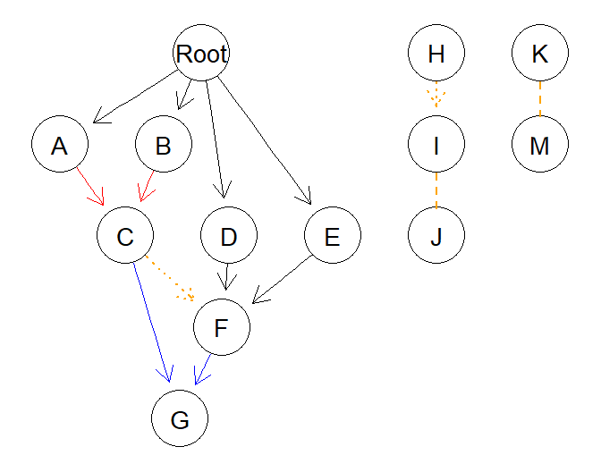

```r
plot(fea)
```

or

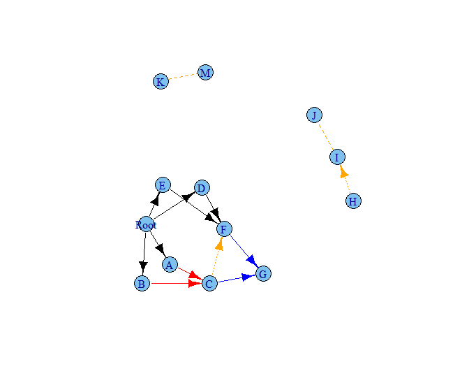

```r
plot(fea, "igraph")
```

We can, if we want, expand the modules using a “graphNEL” graph

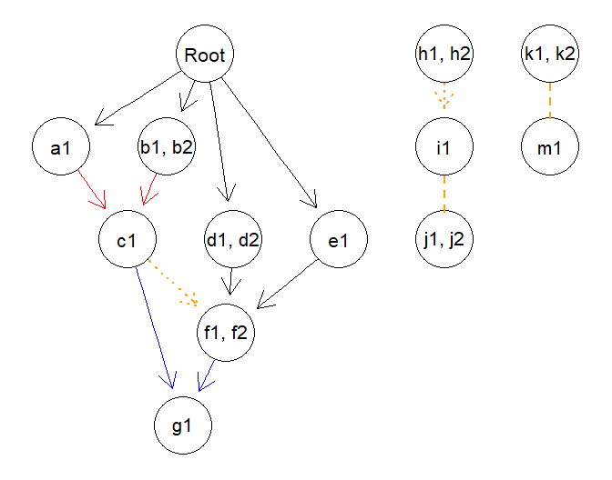

```r
plot(fea, expandModules = TRUE)
```

or an “igraph” one

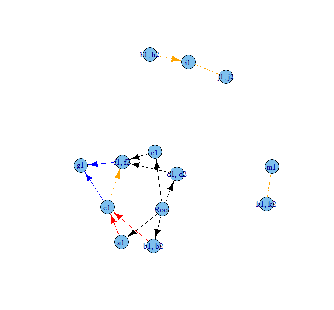

```r
plot(fea, "igraph", expandModules = TRUE)
```

We will not evaluate the fitness of all genotypes, since the number of all ordered genotypes is $> 7*10^{22}$. We will look at some specific genotypes:

```r
evalGenotype("k1 > i1 > h2", fea) ## 0.5
## [1] 0.5
evalGenotype("k1 > h1 > i1", fea) ## 0.5 * 1.12
## [1] 0.56

evalGenotype("k2 > m1 > h1 > i1", fea) ## 1.12
## [1] 1.12

evalGenotype("k2 > m1 > h1 > i1 > c1 > n3 > f2", fea)
## [1] 0.005113436
## 1.12 * 0.1 * (1 + noint[3]) * 0.05 * 0.9
```

Finally, let’s generate some ordered genotypes randomly:

```r
randomGenotype <- function(fe, ns = NULL) {
    gn <- setdiff(c(fe$geneModule$Gene,
                    fe$long.geneNoInt$Gene), "Root")
    if(is.null(ns)) ns <- sample(length(gn), 1)
    return(paste(sample(gn, ns), collapse = " > "))
}

set.seed(2) ## for reproducibility

evalGenotype(randomGenotype(fea), fea, echo = TRUE, verbose = TRUE)
## Genotype:  j2 > d2 > n4 > f1 > k2 > n1 > h2 > i1 > f2 > b1 > h1 > a1 > b2 > n3 > j1 > k1 > e1 > m1 > g1 > c1 > n2
##  Individual s terms are : 0.0755182 0.118164 0.0145707 0.0139795 0.01 0.02 -0.9 0.03 0.04 0.2 0.3 -1 0.12
##  Fitness:  0
## [1] 0
## Genotype:  k2 > i1 > c1 > n1 > m1
##  Individual s terms are : 0.0755182 -0.9
##  Fitness:  0.107552
evalGenotype(randomGenotype(fea), fea, echo = TRUE, verbose = TRUE)
## Genotype:  f2 > j1 > f1 > k1 > i1 > n4
##  Individual s terms are : 0.0139795 -0.95 -1 -0.5
##  Fitness:  0
## [1] 0
## Genotype:  n2 > h1 > h2
##  Individual s terms are : 0.118164
##  Fitness:  1.11816
evalGenotype(randomGenotype(fea), fea, echo = TRUE, verbose = TRUE)
## Genotype:  d2 > n1 > f2 > f1 > i1 > n5 > b1 > e1 > k2 > b2 > c1 > j1 > a1 > k1 > n3 > d1
##  Individual s terms are : 0.0755182 0.0145707 0.0436069 0.01 0.02 -0.9 0.03 0.04 0.2 -1 -0.5
##  Fitness:  0
## [1] 0
## Genotype:  d2 > k2 > c1 > f2 > n4 > m1 > n3 > f1 > b1 > g1 > n5 > h1 > j2
##  Individual s terms are : 0.0145707 0.0139795 0.0436069 0.02 0.1 0.03 -0.95 0.3 -0.1
##  Fitness:  0.0725829
evalGenotype(randomGenotype(fea), fea, echo = TRUE, verbose = TRUE)
## Genotype:  a1 > m1 > f1 > c1 > i1 > d1 > b1 > n4 > d2 > n1 > e1 > k2 > j2 > n2 > g1
##  Individual s terms are : 0.0755182 0.118164 0.0139795 0.01 0.02 -0.9 0.03 0.04 0.2 0.3 -1
##  Fitness:  0
## [1] 0
## Genotype:  h2 > c1 > f1 > n2 > b2 > a1 > n1 > i1
##  Individual s terms are : 0.0755182 0.118164 0.01 0.02 -0.9 -0.95 -0.1 0.12
##  Fitness:  0.00624418
evalGenotype(randomGenotype(fea), fea, echo = TRUE, verbose = TRUE)
## Genotype:  g1 > j2 > m1 > d2 > n1 > n4 > i1 > b2 > f1
##  Individual s terms are : 0.0755182 0.0139795 0.02 0.03 -0.95 0.3 -1 -0.5
##  Fitness:  0
## [1] 0
## Genotype:  h2 > j1 > m1 > d2 > i1 > b2 > k2 > d1 > b1 > n3 > n1 > g1 > h1 > c1 > k1 > e1 > a1 > f1 > n5 > f2
##  Individual s terms are : 0.0755182 0.0145707 0.0436069 0.01 0.02 -0.9 0.03 0.04 0.2 0.3 -1 -0.1 0.12
##  Fitness:  0
evalGenotype(randomGenotype(fea), fea, echo = TRUE, verbose = TRUE)
## Genotype:  i1 > k2 > d1 > d2 > n4 > f2 > j2 > c1 > a1 > j1 > n1 > n3 > h1 > m1 > h2 > b2 > n5 > k1 > e1 > n2 > b1 > g1
##  Individual s terms are : 0.0755182 0.118164 0.0145707 0.0139795 0.0436069 0.01 0.02 -0.9 0.03 0.04 0.2 0.3 -1
##  Fitness:  0
## [1] 0
## Genotype:  n1 > m1 > n3 > i1 > j1 > n5 > k1
##  Individual s terms are : 0.0755182 0.0145707 0.0436069 -1
##  Fitness:  0
evalGenotype(randomGenotype(fea), fea, echo = TRUE, verbose = TRUE)
## Genotype:  n2 > a1 > c1 > d2 > j1 > e1 > k1 > b2 > d1 > n3 > j2 > f2 > i1 > g1 > k2 > h2 > n4 > n5 > m1 > f1 > h1 > n1 > b1
##  Individual s terms are : 0.0755182 0.118164 0.0145707 0.0139795 0.0436069 0.01 0.02 -0.9 0.03 0.04 0.2 0.3 -1 -0.1
##  Fitness:  0
## [1] 0
## Genotype:  d2 > n1 > g1 > f1 > f2 > c1 > b1 > d1 > k1 > a1 > b2 > i1 > n4 > h2 > n2
##  Individual s terms are : 0.0755182 0.118164 0.0139795 0.01 0.02 -0.9 0.03 -0.95 0.3 -0.5
##  Fitness:  0.00420528
evalGenotype(randomGenotype(fea), fea, echo = TRUE, verbose = TRUE)
## Genotype:  d2 > a1 > h2
##  Individual s terms are : 0.01 0.03
##  Fitness:  1.0403
## [1] 1.0403
## Genotype:  j1 > f1 > j2 > a1 > n4 > c1 > n3 > k1 > d1 > h1
##  Individual s terms are : 0.0145707 0.0139795 0.01 0.1 0.03 -0.95 -0.5
##  Fitness:  0.0294308
evalGenotype(randomGenotype(fea), fea, echo = TRUE, verbose = TRUE)
## Genotype:  n2 > f2
##  Individual s terms are : 0.118164 -0.95
##  Fitness:  0.05590821
## [1] 0.05590821
## Genotype:  n5 > f2 > f1 > h2 > n4 > c1 > n3 > b1
##  Individual s terms are : 0.0145707 0.0139795 0.0436069 0.02 0.1 -0.95
##  Fitness:  0.0602298
evalGenotype(randomGenotype(fea), fea, echo = TRUE, verbose = TRUE)
## Genotype:  n5 > n1 > d1 > f1 > c1 > b1 > n2 > i1 > a1 > n3 > n4 > e1 > k2 > b2 > h1 > m1 > j2
##  Individual s terms are : 0.0755182 0.118164 0.0145707 0.0139795 0.0436069 0.01 0.02 -0.9 0.03 0.04 0.2 -1
##  Fitness:  0
## [1] 0
## Genotype:  h1 > d1 > f2
##  Individual s terms are : 0.03 -0.95
##  Fitness:  0.0515
```

## 3.13 Homozygosity, heterozygosity, oncogenes, tumor suppressors

We are using what is conceptually a single linear chromosome. However, you can use it to model scenarios where the numbers of copies affected matter, by properly duplicating the genes.

Suppose we have a tumor suppressor gene, G, with two copies, one from Mom and one from Dad. We can have a table like:

| $O_M$ | $O_D$ | Fitness |
| --- | --- | --- |
| wt | wt | 1 |
| wt | M | 1 |
| M | wt | 1 |
| M | M | $(1 + s)$ |

where $s > 0$, meaning that you need two hits, one in each copy, to trigger the clonal expansion.

What about oncogenes? A simple model is that one single hit leads to clonal expansion and additional hits lead to no additional changes, as in this table for gene O, where again the M or D subscript denotes the copy from Mom or from Dad:

| $O_M$ | $O_D$ | Fitness |
| --- | --- | --- |
| wt | wt | 1 |
| wt | M | $(1 + s)$ |
| M | wt | $(1 + s)$ |
| M | M | $(1 + s)$ |

If you have multiple copies you can proceed similarly. As you can see, these are nothing but special cases of synthetic mortality (3.10), synthetic viability (3.9) and epistasis (3.7).

## 3.14 Gene-specific mutation rates

You can specify gene-specific mutation rates. Instead of passing a scalar value for `mu`, you pass a named vector. (This does not work with the old v. 1 format, though; yet another reason to stop using that format). This is a simple example (many more are available in the tests, see file `./tests/testthat/test.per-gene-mutation-rates.R`).

```r
muvar2 <- c("U" = 1e-6, "z" = 5e-5, "e" = 5e-4, "m" = 5e-3,
            "D" = 1e-4)
ni1 <- rep(0, 5)
names(ni1) <- names(muvar2) ## We use the same names, of course
fe1 <- allFitnessEffects(noIntGenes = ni1)
bb <- oncoSimulIndiv(fe1,
                     mu = muvar2, onlyCancer = FALSE,
                     initSize = 1e5,
                     finalTime = 25,
                     seed =NULL)
```

## 3.15 Mutator genes

You can specify mutator/antimutator genes (e.g. Gerrish et al. 2007; Tomlinson, Novelli, and Bodmer 1996). These are genes that, when mutated, lead to an increase/decrease in the mutation rate all over the genome (similar to what happens with, say, mutations in mismatch-repair genes or microsatellite instability in cancer).

The specification is very similar to that for fitness effects, except we do not (at least for now) allow the use of DAGs nor of order effects (we have seen no reference in the literature to suggest any of these would be relevant). You can, however, specify epistasis and use modules. Note that the mutator genes must be a subset of the genes in the fitness effects; if you want to have mutator genes that have no direct fitness effects, give them a fitness effect of 0.

This first is a very simple example with simple fitness effects and modules for mutators. We will specify the fitness and mutator effects and evaluate the fitness and mutator effects:

```r
fe2 <- allFitnessEffects(noIntGenes =
                         c(a1 = 0.1, a2 = 0.2,
                           b1 = 0.01, b2 = 0.3, b3 = 0.2,
                           c1 = 0.3, c2 = -0.2))

fm2 <- allMutatorEffects(epistasis = c("A" = 5,
                                       "B" = 10,
                                       "C" = 3),
                         geneToModule = c("A" = "a1, a2",
                                          "B" = "b1, b2, b3",
                                          "C" = "c1, c2"))

## Show the fitness effect of a specific genotype
evalGenotype("a1, c2", fe2, verbose = TRUE)
##
##  Individual s terms are : 0.1 -0.2
## [1] 0.88

## Show the mutator effect of a specific genotype
evalGenotypeMut("a1, c2", fm2, verbose = TRUE)
##
##  Individual mutator product terms are : 5 3
## [1] 15

## Fitness and mutator of a specific genotype
evalGenotypeFitAndMut("a1, c2", fe2, fm2, verbose = TRUE)
##
##  Individual s terms are : 0.1 -0.2
##
##  Individual mutator product terms are : 5 3
## [1]  0.88 15.00
```

You can also use the `evalAll` functions. We do not show the output here to avoid cluttering the vignette:

```r
## Show only all the fitness effects
evalAllGenotypes(fe2, order = FALSE)

## Show only all mutator effects
evalAllGenotypesMut(fm2)

## Show all fitness and mutator
evalAllGenotypesFitAndMut(fe2, fm2, order = FALSE)
```

Building upon the above, the next is an example where we have a bunch of no interaction genes that affect fitness, and a small set of genes that affect the mutation rate (but have no fitness effects).

```r
set.seed(1) ## for reproducibility
## 17 genes, 7 with no direct fitness effects
ni <- c(rep(0, 7), runif(10, min = -0.01, max = 0.1))
names(ni) <- c("a1", "a2", "b1", "b2", "b3", "c1", "c2",
               paste0("g", 1:10))

fe3 <- allFitnessEffects(noIntGenes = ni)

fm3 <- allMutatorEffects(epistasis = c("A" = 5,
                                       "B" = 10,
                                       "C" = 3,
                                       "A:C" = 70),
                         geneToModule = c("A" = "a1, a2",
                                          "B" = "b1, b2, b3",
                                          "C" = "c1, c2"))
```

Let us check what the effects are of a few genotypes:

```r
## These only affect mutation, not fitness
evalGenotypeFitAndMut("a1, a2", fe3, fm3, verbose = TRUE)
##
##  Individual s terms are : 0 0
##
##  Individual mutator product terms are : 5
## [1] 1 5
evalGenotypeFitAndMut("a1, b3", fe3, fm3, verbose = TRUE)
##
##  Individual s terms are : 0 0
##
##  Individual mutator product terms are : 5 10
## [1]  1 50

## These only affect fitness: the mutator multiplier is 1
evalGenotypeFitAndMut("g1", fe3, fm3, verbose = TRUE)
##
##  Individual s terms are : 0.019206
## [1] 1.019206 1.000000
evalGenotypeFitAndMut("g3, g9", fe3, fm3, verbose = TRUE)
##
##  Individual s terms are : 0.0530139 0.0592025
## [1] 1.115355 1.000000

## These affect both
evalGenotypeFitAndMut("g3, g9, a2, b3", fe3, fm3, verbose = TRUE)
##
##  Individual s terms are : 0 0 0.0530139 0.0592025
##
##  Individual mutator product terms are : 5 10
## [1]  1.115355 50.000000
```

Finally, we will do a simulation with those data

```r
set.seed(1) ## so that it is easy to reproduce
mue1 <- oncoSimulIndiv(fe3, muEF = fm3,
                       mu = 1e-6,
                       initSize = 1e5,
                       model = "McFL",
                       detectionSize = 5e6,
                       finalTime = 500,
                       onlyCancer = FALSE)
```

```r
## We do not show this in the vignette to avoid cluttering it
## with output
mue1
```

Of course, it is up to you to keep things reasonable: mutator effects are multiplicative, so if you specify, say, 20 genes (without modules), or 20 modules, each with a mutator effect of 50, the overall mutation rate can be increased by a factor of $50^{20}$ and that is unlikely to be what you really want (see also section 15.7).

You can play with the following case (an extension of the example above), where a clone with a mutator phenotype and some fitness enhancing mutations starts giving rise to many other clones, some with additional mutator effects, and thus leading to the number of clones blowing up (as some also accumulate additional fitness-enhancing mutations). Things start getting out of hand shortly after time 250. The code below takes a few minutes to run and is not executed here, but you can run it to get an idea of the increase in the number of clones and their relationships (the usage of `plotClonePhylog` is explained in section 8).

```r
set.seed(1) ## for reproducibility
## 17 genes, 7 with no direct fitness effects
ni <- c(rep(0, 7), runif(10, min = -0.01, max = 0.1))
names(ni) <- c("a1", "a2", "b1", "b2", "b3", "c1", "c2",
               paste0("g", 1:10))

## Next is for nicer figure labeling.
## Consider as drivers genes with s >0
gp <- which(ni > 0)

fe3 <- allFitnessEffects(noIntGenes = ni,
                         drvNames = names(ni)[gp])


set.seed(12)
mue1 <- oncoSimulIndiv(fe3, muEF = fm3,
                       mu = 1e-6,
                       initSize = 1e5,
                       model = "McFL",
                       detectionSize = 5e6,
                       finalTime = 270,
                       keepPhylog = TRUE,
                       onlyCancer = FALSE)
mue1
## If you decrease N even further it gets even more cluttered
op <- par(ask = TRUE)
plotClonePhylog(mue1, N = 10, timeEvents = TRUE)
plot(mue1, plotDrivers = TRUE, addtot = TRUE,
     plotDiversity = TRUE)

## The stacked plot is slow; be patient
## Most clones have tiny population sizes, and their lines
## are piled on top of each other
plot(mue1, addtot = TRUE,
     plotDiversity = TRUE, type = "stacked")
par(op)
```

# 4 Plotting fitness landscapes

The `evalAllGenotypes` and related functions allow you to obtain tables of the genotype to fitness mappings. It might be more convenient to actually plot that, allowing us to quickly identify local minima and maxima and get an idea of how the fitness landscape looks.

In `plotFitnessLandscape` I have blatantly and shamelessly copied most of the looks of the plots of MAGELLAN (Brouillet et al. 2015) (see also http://wwwabi.snv.jussieu.fr/public/Magellan/), a very nice web-based tool for fitness landscape plotting and analysis (MAGELLAN provides some other extra functionality and epistasis statistics not provided here).

As an example, let us show the example of Weissman et al. we saw in 5.4:

```r
d1 <- -0.05 ## single mutant fitness 0.95
d2 <- -0.08 ## double mutant fitness 0.92
d3 <- 0.2   ## triple mutant fitness 1.2
s2 <- ((1 + d2)/(1 + d1)^2) - 1
s3 <- ( (1 + d3)/((1 + d1)^3 * (1 + s2)^3) ) - 1

wb <- allFitnessEffects(
    epistasis = c(
        "A" = d1,
        "B" = d1,
        "C" = d1,
        "A:B" = s2,
        "A:C" = s2,
        "B:C" = s2,
        "A:B:C" = s3))
```

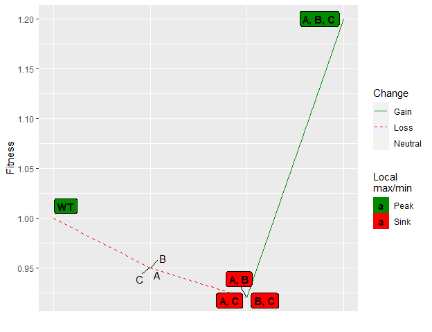

```r
plotFitnessLandscape(wb, use_ggrepel = TRUE)
```

We have set `use_ggrepel = TRUE` to avoid overlap of labels.

For some types of objects, directly invoking `plot` will give you the fitness landscape plot:

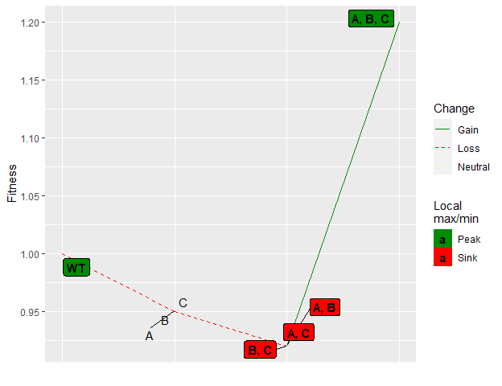

```r
(ewb <- evalAllGenotypes(wb, order = FALSE))
##   Genotype Fitness
## 1        A    0.95
## 2        B    0.95
## 3        C    0.95
## 4     A, B    0.92
## 5     A, C    0.92
## 6     B, C    0.92
## 7  A, B, C    1.20
plot(ewb, use_ggrepel = TRUE)
```

This is example (section 5.5) will give a very busy plot:

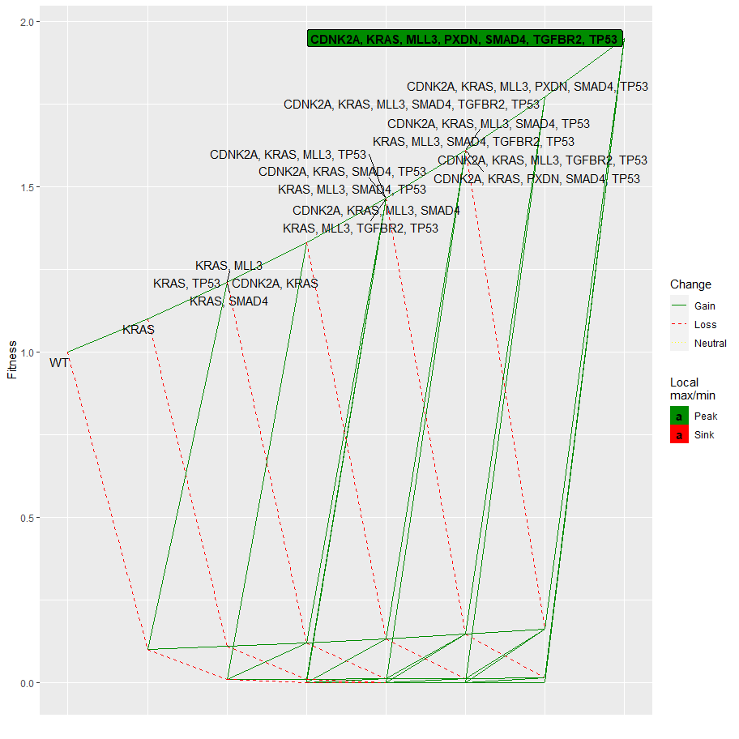

```r
par(cex = 0.7)
pancr <- allFitnessEffects(
    data.frame(parent = c("Root", rep("KRAS", 4),
                   "SMAD4", "CDNK2A",
                   "TP53", "TP53", "MLL3"),
               child = c("KRAS","SMAD4", "CDNK2A",
                   "TP53", "MLL3",
                   rep("PXDN", 3), rep("TGFBR2", 2)),
               s = 0.1,
               sh = -0.9,
               typeDep = "MN"))
plot(evalAllGenotypes(pancr, order = FALSE), use_ggrepel = TRUE)
## Warning: ggrepel: 103 unlabeled data points (too many overlaps).
## Consider increasing max.overlaps
## Warning: ggrepel: 7 unlabeled data points (too many overlaps).
## Consider increasing max.overlaps
```

# 5 Specifying fitness effects: some examples from the literature

## 5.1 Bauer et al., 2014

In the model of Bauer and collaborators (Bauer, Siebert, and Traulsen 2014, 54) we have “For cells without the primary driver mutation, each secondary driver mutation leads to a change in the cell’s fitness by $s_P$. For cells with the primary driver mutation, the fitness advantage obtained with each secondary driver mutation is $s_{DP}$.”

The proliferation probability is given as:

- $\frac{1}{2}(1 + s_p)^k$ when there are $k$ secondary drivers mutated and no primary diver;
- $\frac{1}{2}\frac{1+S_D^+}{1+S_D^-} (1 + S_{DP})^k$ when the primary driver is mutated;

apoptosis is one minus the proliferation rate.

### 5.1.1 Using a DAG

We cannot find a simple mapping from their expressions to our fitness parameterization, but we can get fairly close by using a DAG; in this one, note the unusual feature of having one of the “s” terms (that for the driver dependency on root) be negative. Using the parameters given in the legend of their Figure 3 for $s_p, S_D^+, S_D^-, S_{DP}$ and obtaining that negative value for the dependency of the driver on root we can do:

```r
K <- 4
sp <- 1e-5
sdp <- 0.015
sdplus <- 0.05
sdminus <- 0.1
cnt <- (1 + sdplus)/(1 + sdminus)
prod_cnt <- cnt - 1
bauer <- data.frame(parent = c("Root", rep("D", K)),
                    child = c("D", paste0("s", 1:K)),
                    s = c(prod_cnt, rep(sdp, K)),
                    sh = c(0, rep(sp, K)),
                    typeDep = "MN")
fbauer <- allFitnessEffects(bauer)
(b1 <- evalAllGenotypes(fbauer, order = FALSE, addwt = TRUE))
##             Genotype   Fitness
## 1                 WT 1.0000000
## 2                  D 0.9545455
## 3                 s1 1.0000100
## 4                 s2 1.0000100
## 5                 s3 1.0000100
## 6                 s4 1.0000100
## 7              D, s1 0.9688636
## 8              D, s2 0.9688636
## 9              D, s3 0.9688636
## 10             D, s4 0.9688636
## 11            s1, s2 1.0000200
## 12            s1, s3 1.0000200
## 13            s1, s4 1.0000200
## 14            s2, s3 1.0000200
## 15            s2, s4 1.0000200
## 16            s3, s4 1.0000200
## 17         D, s1, s2 0.9833966
## 18         D, s1, s3 0.9833966
## 19         D, s1, s4 0.9833966
## 20         D, s2, s3 0.9833966
## 21         D, s2, s4 0.9833966
## 22         D, s3, s4 0.9833966
## 23        s1, s2, s3 1.0000300
## 24        s1, s2, s4 1.0000300
## 25        s1, s3, s4 1.0000300
## 26        s2, s3, s4 1.0000300
## 27     D, s1, s2, s3 0.9981475
## 28     D, s1, s2, s4 0.9981475
## 29     D, s1, s3, s4 0.9981475
## 30     D, s2, s3, s4 0.9981475
## 31    s1, s2, s3, s4 1.0000400
## 32 D, s1, s2, s3, s4 1.0131198
```

(We use “D” for “driver” or “primary driver”, as is it is called in the original paper, and “s” for secondary drivers, somewhat similar to passengers).

Note that what we specify as “typeDep” is irrelevant (MN, SMN, or XMPN make no difference).

This is the DAG:

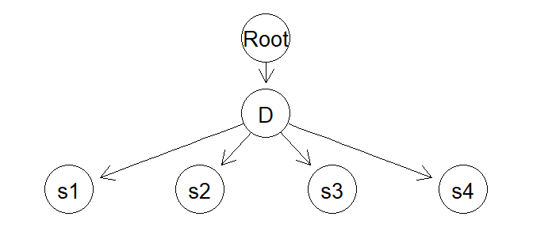

```r
plot(fbauer)
```

And if you compare the tabular output of `evalAllGenotypes` you can see that the values of fitness reproduces the fitness landscape that they show in their Figure 1. We can also use our plot for fitness landscapes:

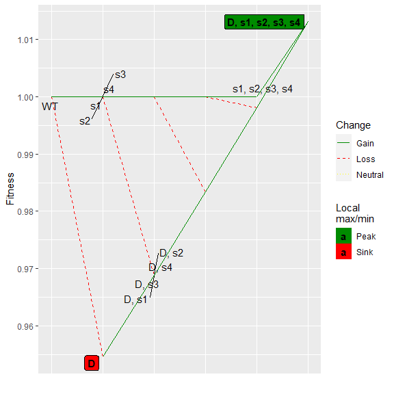

```r
plot(b1, use_ggrepel = TRUE)
## Warning: ggrepel: 20 unlabeled data points (too many overlaps).
## Consider increasing max.overlaps
```

### 5.1.2 Specifying fitness of genotypes directly

An alternative approach to specify the fitness, if the number of genotypes is reasonably small, is to directly evaluate fitness as given by their expressions. Then, use the `genotFitness` argument to `allFitnessEffects`.

We will create all possible genotypes; then we will write a function that gives the fitness of each genotype according to their expression; finally, we will call this function on the data frame of genotypes, and pass this data frame to `allFitnessEffects`.

```r
m1 <- expand.grid(D = c(1, 0), s1 = c(1, 0), s2 = c(1, 0),
                  s3 = c(1, 0), s4 = c(1, 0))

fitness_bauer <- function(D, s1, s2, s3, s4,
                          sp = 1e-5, sdp = 0.015, sdplus = 0.05,
                          sdminus = 0.1) {
    if(!D) {
        b <- 0.5 * ( (1 + sp)^(sum(c(s1, s2, s3, s4))))
    } else {
        b <- 0.5 *
            (((1 + sdplus)/(1 + sdminus)  *
              (1 + sdp)^(sum(c(s1, s2, s3, s4)))))
    }
    fitness <- b - (1 - b)
    our_fitness <- 1 + fitness ## prevent negative fitness and
    ## make wt fitness = 1
    return(our_fitness)
}

m1$Fitness <-
    apply(m1, 1, function(x) do.call(fitness_bauer, as.list(x)))

bauer2 <- allFitnessEffects(genotFitness = m1)
```

Now, show the fitness of all genotypes:

```r
evalAllGenotypes(bauer2, order = FALSE, addwt = TRUE)
##             Genotype   Fitness
## 1                 WT 1.0000000
## 2                  D 0.9545455
## 3                 s1 1.0000100
## 4                 s2 1.0000100
## 5                 s3 1.0000100
## 6                 s4 1.0000100
## 7              D, s1 0.9688636
## 8              D, s2 0.9688636
## 9              D, s3 0.9688636
## 10             D, s4 0.9688636
## 11            s1, s2 1.0000200
## 12            s1, s3 1.0000200
## 13            s1, s4 1.0000200
## 14            s2, s3 1.0000200
## 15            s2, s4 1.0000200
## 16            s3, s4 1.0000200
## 17         D, s1, s2 0.9833966
## 18         D, s1, s3 0.9833966
## 19         D, s1, s4 0.9833966
## 20         D, s2, s3 0.9833966
## 21         D, s2, s4 0.9833966
## 22         D, s3, s4 0.9833966
## 23        s1, s2, s3 1.0000300
## 24        s1, s2, s4 1.0000300
## 25        s1, s3, s4 1.0000300
## 26        s2, s3, s4 1.0000300
## 27     D, s1, s2, s3 0.9981475
## 28     D, s1, s2, s4 0.9981475
## 29     D, s1, s3, s4 0.9981475
## 30     D, s2, s3, s4 0.9981475
## 31    s1, s2, s3, s4 1.0000400
## 32 D, s1, s2, s3, s4 1.0131198
```

Can we use modules in this example, if we use the “lego system”? Sure, as in any other case.

## 5.2 Misra et al., 2014

Figure 1 of Misra, Szczurek, and Vingron (2014) presents three scenarios which are different types of epistasis.

### 5.2.1 Example 1.a

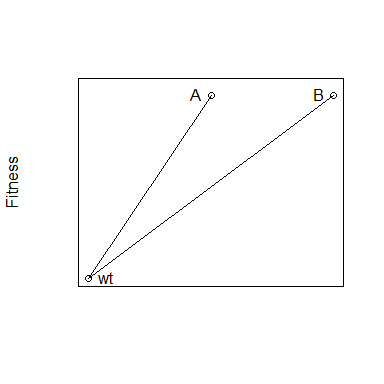

In that figure it is evident that the fitness effect of “A” and “B” are the same. There are two different models depending on whether “AB” is just the product of both, or there is epistasis. In the first case probably the simplest is:

```r
s <- 0.1 ## or whatever number
m1a1 <- allFitnessEffects(data.frame(parent = c("Root", "Root"),
                                     child = c("A", "B"),
                                     s = s,
                                     sh = 0,
                                     typeDep = "MN"))
evalAllGenotypes(m1a1, order = FALSE, addwt = TRUE)
##   Genotype Fitness
## 1       WT    1.00
## 2        A    1.10
## 3        B    1.10
## 4     A, B    1.21
```

If the double mutant shows epistasis, as we saw before (section 3.7.1) we have a range of options. For example:

```r
s <- 0.1
sab <- 0.3
m1a2 <- allFitnessEffects(epistasis = c("A:-B" = s,
                                        "-A:B" = s,
                                        "A:B" = sab))
evalAllGenotypes(m1a2, order = FALSE, addwt = TRUE)
##   Genotype Fitness
## 1       WT     1.0
## 2        A     1.1
## 3        B     1.1
## 4     A, B     1.3
```

But we could also modify the graph dependency structure, and we have to change the value of the coefficient, since that is what multiplies each of the terms for “A” and “B”: $(1 + s_{AB}) = (1 + s)^2(1 + s_{AB3})$

```r
sab3 <- ((1 + sab)/((1 + s)^2)) - 1
m1a3 <- allFitnessEffects(data.frame(parent = c("Root", "Root"),
                                     child = c("A", "B"),
                                     s = s,
                                     sh = 0,
                                     typeDep = "MN"),
                          epistasis = c("A:B" = sab3))
evalAllGenotypes(m1a3, order = FALSE, addwt = TRUE)
##   Genotype Fitness
## 1       WT     1.0
## 2        A     1.1
## 3        B     1.1
## 4     A, B     1.3
```

And, obviously

```r
all.equal(evalAllGenotypes(m1a2, order = FALSE, addwt = TRUE),
          evalAllGenotypes(m1a3, order = FALSE, addwt = TRUE))
## [1] TRUE
```